# Customer Churn Analysis

#### 3.3.4 Status Relationship – Numeric Variables selection: Tenure, Monthly Charges, TotalCharges

We now turn our attention to **numerical variables**—`Tenure`, `MonthlyCharges`, and `TotalCharges`—to investigate how these continuous attributes differ between customers who stayed and those who left.

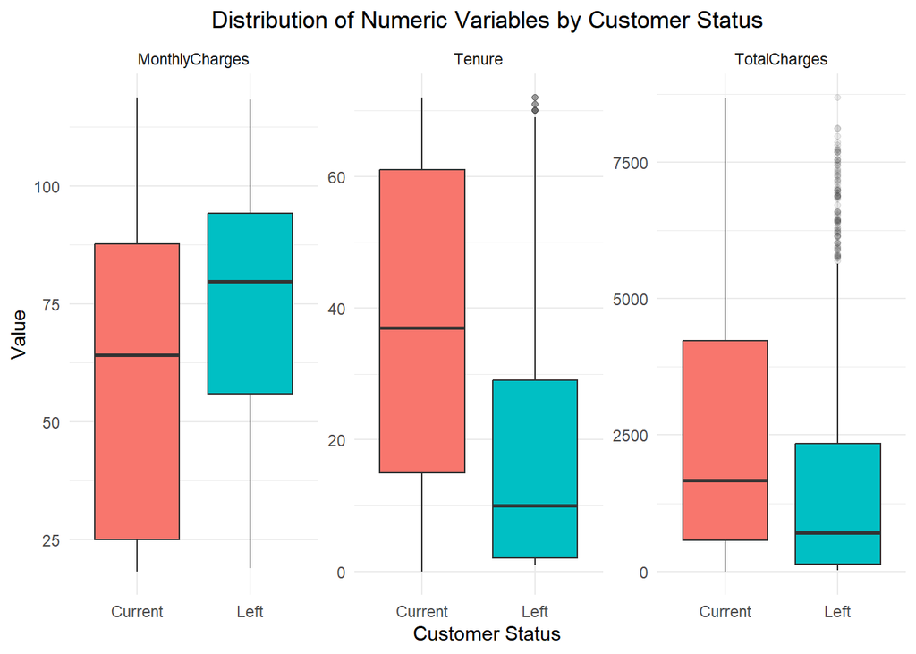

```r
# Select numeric variables and churn status
numeric_status_data <- Model_Building_Data_cleaned %>%
  dplyr::select(Status, Tenure, MonthlyCharges, TotalCharges)

# Convert to long format for faceted plotting
numeric_status_long <- numeric_status_data %>%
  pivot_longer(cols = -Status, names_to = "Variable", values_to = "Value")

# Plot faceted boxplots comparing churned vs retained customers
ggplot(data = numeric_status_long, mapping = aes(x = Status, y = Value, fill = Status)) +
  geom_boxplot(outlier.alpha = 0.1) +
  facet_wrap(~ Variable, scales = "free") +
  # add labels and title
  labs(
    title = "Distribution of Numeric Variables by Customer Status",
    x = "Customer Status",
    y = "Value"
  ) +
  # apply theme
  theme_minimal() +
  theme(
    plot.title = element_text(hjust = 0.5),
    legend.position = "none"
  )
```

Churn Patterns in Numeric Variables (Boxplot Analysis)

The boxplot chart reveals **notable contrasts** in churn behavior across key numeric variables:

- **Tenure** shows the **most significant difference** between churned and retained customers.  
  Those who **stayed** with the company had a **much longer service duration** — their median tenure is **over three times higher** than that of those who churned.  
  This highlights that **early-stage customers are far more at risk**, making tenure a **critical indicator** for churn prediction.
- **MonthlyCharges** are **slightly higher** among churned customers.  
  While the gap is modest, it suggests that **higher-cost plans may carry a greater churn risk**, possibly due to price sensitivity.  
  However, this pattern needs further confirmation through modeling.
- **TotalCharges** is naturally **lower for churned customers**, reflecting their shorter time with the company.  
  This variable aligns more closely with **customer lifetime value**, which can be helpful in identifying **high-value customers at risk**.

In summary, **Tenure emerges as the strongest numeric signal** of churn and will be a key input in the predictive models that follow.

### 3.4 Create engineered features to support modeling and segmentation

```r
Model_Building_Data_cleaned <- Model_Building_Data_cleaned %>%
  mutate(
    # Long-term loyalty proxy
    IsLongTermCustomer = ifelse(Tenure >= 12, "Yes", "No"),

    # Monthly payment above median
    IsHighCharge = ifelse(MonthlyCharges > median(MonthlyCharges), "Yes", "No"),

    # Cumulative high-value customer (top 25%)
    IsHighValueCustomer = ifelse(TotalCharges > quantile(TotalCharges, 0.75, na.rm = TRUE), "Yes", "No"),

    # Customer is on a non-month-to-month contract
    IsContractLocked = ifelse(Contract != "Month-to-month", "Yes", "No"),

    # Customer has all 3 major services: Phone, Internet, Security & Protection
    HasFullService = ifelse(
      PhoneService == "Yes" &
      InternetService != "No" &
      OnlineSecurity == "Yes" &
      DeviceProtection == "Yes",
      "Yes", "No"),

    # Proxy for digital readiness: not a senior & uses paperless billing
    IsTechComfortable = ifelse(
      SeniorCitizen == 0 & PaperlessBilling == "Yes",
      "Yes", "No"),

    # Count how many services the customer has, then bin into Low (0–2) and High (3–5)
    ServiceCount = rowSums(across(
      c(PhoneService, MultipleLines, OnlineSecurity, DeviceProtection, StreamingMovies),
      ~ .x == "Yes"
    )),
    ServiceCountGroup = case_when(
      ServiceCount <= 2 ~ "Low",
      ServiceCount >= 3 ~ "High"
    )
  ) %>%
  # Convert all new categorical variables to factors
  mutate(across(
    c(IsLongTermCustomer, IsHighCharge, IsHighValueCustomer,
      IsContractLocked, HasFullService, IsTechComfortable, ServiceCountGroup),
    as.factor
  ))
```

Feature Engineering for Business Insight and Model Clarity

In addition to cleaning existing variables, we created several new features designed to enhance both **model interpretability** and **business relevance**:

- **IsLongTermCustomer**  
  Flags whether a customer has been with the company for **more than 12 months**, serving as a proxy for **customer loyalty**.
- **IsHighCharge**  
  Identifies customers with **above-median monthly charges**, who may be **more price sensitive** and potentially at higher risk of churn.
- **IsHighValueCustomer**  
  Tags customers in the **top 25% of total charges**, representing those with **high lifetime value**.
- **IsContractLocked**  
  Highlights customers on **one- or two-year contracts**, who are likely **less prone to churn** due to higher switching barriers.
- **HasFullService**  
  Captures customers subscribed to **all core services** (phone, internet, and protection), indicating **deeper engagement** with the company.
- **IsTechComfortable**  
  Combines **non-senior age** and **paperless billing** as a signal of **digital readiness**, which may affect service preferences and communication response.
- **ServiceCount**  
  Counts the number of subscribed services per customer, serving as a simple measure of **engagement depth** or **product stickiness**.

After creating the new **feature variables**, it is important to verify the **updated structure** of the dataset to ensure all variables are correctly formatted and ready for **modeling**.

```r
# check the dataset structure
str(Model_Building_Data_cleaned,10)
```

```
## 'data.frame':    6499 obs. of  25 variables:
##  $ Gender             : Factor w/ 2 levels "Female","Male": 1 2 2 2 1 1 2 1 1 2 ...
##  $ SeniorCitizen      : Factor w/ 2 levels "0","1": 1 1 1 1 1 1 1 1 1 1 ...
##  $ Partner            : Factor w/ 2 levels "No","Yes": 2 1 1 1 1 1 1 1 2 1 ...
##  $ Dependents         : Factor w/ 2 levels "No","Yes": 1 1 1 1 1 1 2 1 1 2 ...
##  $ Tenure             : int  1 34 2 45 2 8 22 10 28 62 ...
##  $ PhoneService       : Factor w/ 2 levels "No","Yes": 1 2 2 1 2 2 2 1 2 2 ...
##  $ MultipleLines      : Factor w/ 3 levels "No","No phone service",..: 2 1 1 2 1 3 3 2 3 1 ...
##  $ InternetService    : Factor w/ 3 levels "DSL","Fiber optic",..: 1 1 1 1 2 2 2 1 2 1 ...
##  $ OnlineSecurity     : Factor w/ 3 levels "No","No internet service",..: 1 3 3 3 1 1 1 3 1 3 ...
##  $ DeviceProtection   : Factor w/ 3 levels "No","No internet service",..: 1 3 1 3 1 3 1 1 3 1 ...
##  $ StreamingMovies    : Factor w/ 3 levels "No","No internet service",..: 1 1 1 1 1 3 1 1 3 1 ...
##  $ Contract           : Factor w/ 3 levels "Month-to-month",..: 1 2 1 2 1 1 1 1 1 2 ...
##  $ PaperlessBilling   : Factor w/ 2 levels "No","Yes": 2 1 2 1 2 2 2 1 2 1 ...
##  $ PaymentMethod      : Factor w/ 4 levels "Bank transfer (automatic)",..: 3 4 4 1 3 3 2 4 3 1 ...
##  $ MonthlyCharges     : num  29.9 57 53.9 42.3 70.7 ...
##  $ TotalCharges       : num  29.9 1889.5 108.2 1840.8 151.7 ...
##  $ Status             : Factor w/ 2 levels "Current","Left": 1 1 2 1 2 2 1 1 2 1 ...
##  $ IsLongTermCustomer : Factor w/ 2 levels "No","Yes": 1 2 1 2 1 1 2 1 2 2 ...
##  $ IsHighCharge       : Factor w/ 2 levels "No","Yes": 1 1 1 1 2 2 2 1 2 1 ...
##  $ IsHighValueCustomer: Factor w/ 2 levels "No","Yes": 1 1 1 1 1 1 1 1 1 1 ...
##  $ IsContractLocked   : Factor w/ 2 levels "No","Yes": 1 2 1 2 1 1 1 1 1 2 ...
##  $ HasFullService     : Factor w/ 2 levels "No","Yes": 1 2 1 1 1 1 1 1 1 1 ...
##  $ IsTechComfortable  : Factor w/ 2 levels "No","Yes": 2 1 2 1 2 2 2 1 2 1 ...
##  $ ServiceCount       : num  0 3 2 2 1 4 2 1 4 2 ...
##  $ ServiceCountGroup  : Factor w/ 2 levels "High","Low": 2 1 2 2 2 1 2 2 1 2 ...
```

The structure check confirms that all **variables** are well-organized and properly **formatted** for downstream **analysis**.

These features not only improve model flexibility but also help uncover key behavioral signals that can inform retention strategy.

### 3.5 Splitting data into training (80%) and testing (20%) sets

To ensure reliable model evaluation, the dataset was split into **training** (80%) and **testing** (20%) subsets, allowing us to assess **model performance** on unseen data.

```r
# Set seed for reproducibility
set.seed(620)

# Generate training set index: 80% of data
train_index <- sample(1:nrow(Model_Building_Data_cleaned),
                      size = 0.8 * nrow(Model_Building_Data_cleaned))

# Create training and test sets
training_set <- Model_Building_Data_cleaned[train_index, ]
test_set <- Model_Building_Data_cleaned[-train_index, ]
```

```r
# Check if the division is successful
nrow(training_set)
```

```
## [1] 5199
```

```r
nrow(test_set)
```

```
## [1] 1300
```

To build and evaluate our predictive models fairly, we split the data into two parts:  
* **Training set**: 5,199 observations, used to train the model  
* **Testing set**: 1,300 observations, used to evaluate how well the model performs on unseen data

This approach ensures that we can test our model’s accuracy **without bias**, providing more reliable and realistic results.

These features not only improve model flexibility but also help uncover key behavioral signals that can inform retention strategy.

## 4. Logistic Regression

### 4.1 Use the training set to build a Logistic Regression model to predict the probability for losing a customer.

To estimate the probability of customer churn, we applied a **Logistic Regression model** using the **training dataset**. This method is appropriate for binary classification tasks and helps us **evaluate how each variable influences the likelihood of churn.**

```r
# Convert Status to binary response: "Left" = 1, "Current" = 0
training_set <- training_set %>%
  mutate(Status_bin = ifelse(Status == "Left", 1, 0))

test_set <- test_set %>%
  mutate(Status_bin = ifelse(Status == "Left", 1, 0))
```

```r
# Build logistic regression model using training data with all vriables
logit_full <- glm(Status_bin ~ . - Status,
                  data = training_set,
                  family = "binomial")
```

```r
# View model summary
summary(logit_full)
```

```
##
## Call:
## glm(formula = Status_bin ~ . - Status, family = "binomial", data = training_set)
##
## Coefficients: (6 not defined because of singularities)
##                                        Estimate Std. Error z value Pr(>|z|)
## (Intercept)                          -2.776e-01  3.760e-01  -0.738 0.460332
## GenderMale                            3.796e-02  7.516e-02   0.505 0.613470
## SeniorCitizen1                        2.980e-01  1.962e-01   1.519 0.128786
## PartnerYes                            7.480e-02  9.052e-02   0.826 0.408584
## DependentsYes                        -1.259e-01  1.033e-01  -1.219 0.222882
## Tenure                               -4.236e-02  8.321e-03  -5.090 3.58e-07 ***
## PhoneServiceYes                      -4.109e-01  2.112e-01  -1.946 0.051704 .
## MultipleLinesNo phone service                NA         NA      NA       NA
## MultipleLinesYes                      3.824e-01  1.149e-01   3.329 0.000873 ***
## InternetServiceFiber optic            1.036e+00  2.239e-01   4.629 3.68e-06 ***
## InternetServiceNo                    -8.524e-01  2.733e-01  -3.119 0.001816 **
## OnlineSecurityNo internet service            NA         NA      NA       NA
## OnlineSecurityYes                    -2.947e-01  1.333e-01  -2.211 0.027065 *
## DeviceProtectionNo internet service          NA         NA      NA       NA
## DeviceProtectionYes                   7.931e-02  1.220e-01   0.650 0.515600
## StreamingMoviesNo internet service           NA         NA      NA       NA
## StreamingMoviesYes                    4.630e-01  1.438e-01   3.219 0.001285 **
## ContractOne year                     -7.006e-01  1.244e-01  -5.632 1.78e-08 ***
## ContractTwo year                     -1.538e+00  2.016e-01  -7.630 2.35e-14 ***
## PaperlessBillingYes                   2.407e-01  2.009e-01   1.198 0.230897
## PaymentMethodCredit card (automatic) -1.255e-01  1.321e-01  -0.950 0.341923
## PaymentMethodElectronic check         3.104e-01  1.096e-01   2.833 0.004609 **
## PaymentMethodMailed check            -2.493e-02  1.341e-01  -0.186 0.852532
## MonthlyCharges                       -5.568e-03  7.915e-03  -0.704 0.481729
## TotalCharges                          2.107e-04  9.781e-05   2.155 0.031200 *
## IsLongTermCustomerYes                -4.737e-01  1.348e-01  -3.515 0.000441 ***
## IsHighChargeYes                       6.651e-02  1.776e-01   0.374 0.708119
## IsHighValueCustomerYes                1.720e-02  2.079e-01   0.083 0.934083
## IsContractLockedYes                          NA         NA      NA       NA
## HasFullServiceYes                    -4.286e-02  1.950e-01  -0.220 0.825989
## IsTechComfortableYes                  1.146e-01  2.194e-01   0.522 0.601569
## ServiceCount                                 NA         NA      NA       NA
## ServiceCountGroupLow                  2.797e-01  1.556e-01   1.798 0.072235 .
## ---
## Signif. codes:  0 '***' 0.001 '**' 0.01 '*' 0.05 '.' 0.1 ' ' 1
##
## (Dispersion parameter for binomial family taken to be 1)
##
##     Null deviance: 6055.3  on 5198  degrees of freedom
## Residual deviance: 4346.8  on 5172  degrees of freedom
## AIC: 4400.8
##
## Number of Fisher Scoring iterations: 6
```

Specifically, the following variables had **NA coefficients**, meaning the model could not estimate their effect:

- **MultipleLinesNo phone service**
- **OnlineSecurityNo internet service**
- **DeviceProtectionNo internet service**
- **StreamingMoviesNo internet service**
- **IsContractLockedYes**
- **ServiceCount**

This suggests that there is **perfect multicollinearity**—some variables are too closely related to others, or are **redundant**, causing the model to become unstable or unreliable.

To solve this, we applied a **regularized logistic regression model**, specifically **Lasso (L1 regularization)**. This method automatically selects the most important variables by **shrinking less useful ones to zero**, helping us build a **simpler and more interpretable model**.

Regularization also helps prevent **overfitting**—when a model performs well on training data but poorly on new data—by improving its ability to **generalize** to unseen cases. This is especially useful when we have many overlapping or derived features in the dataset.

#### 4.1.1 Lasso Regression Model (with Cross-Validation)

```r
# Construct x (predictor matrix) and y (response vector)
x <- model.matrix(Status_bin ~ . - Status, data = training_set)[, -1]
y <- training_set$Status_bin

# Set lambda grid
grid <- 10^seq(10, -2, length = 100)

# Fit Lasso regression model across the grid of lambda values
lasso.mod <- glmnet(x, y, alpha = 1, lambda = grid,family = "binomial")
```

```r
# Perform 10-fold cross-validation to find best lambda
set.seed(1528)
cv.out <- cv.glmnet(x, y, alpha = 1,family = "binomial")

# Extract the best lambda
bestlambda <- cv.out$lambda.min
```

To address **multicollinearity** (when variables are too closely related) and improve model clarity, we employed **Lasso Regression** with **cross-validation** on the training dataset.

Lasso is a type of regularized regression that performs **automatic variable selection** by shrinking less important variables toward zero. This helps create a **simpler, more interpretable model** without sacrificing predictive power.

By combining Lasso with cross-validation (a method to test model stability), we ensure that the model remains **robust and generalizable**, even when faced with complex or overlapping features.

This approach allows us to focus on the **most relevant predictors**, which is especially helpful when making business decisions based on the model’s output.

```r
# Refit the model using the full grid
out <- glmnet(x, y, alpha = 1, lambda = grid)

# Extract coefficients at the best lambda
lasso.coef <- predict(out, type = "coefficients", s = bestlambda)
lasso.coef
```

```
## 33 x 1 sparse Matrix of class "dgCMatrix"
##                                                 s1
## (Intercept)                           3.602454e-01
## GenderMale                            .
## SeniorCitizen1                        3.149888e-02
## PartnerYes                            .
## DependentsYes                        -2.154482e-04
## Tenure                               -4.871145e-04
## PhoneServiceYes                       .
## MultipleLinesNo phone service         .
## MultipleLinesYes                      1.629266e-02
## InternetServiceFiber optic            1.790749e-01
## InternetServiceNo                    -9.429136e-02
## OnlineSecurityNo internet service    -6.036518e-15
## OnlineSecurityYes                    -4.383432e-02
## DeviceProtectionNo internet service   .
## DeviceProtectionYes                   .
## StreamingMoviesNo internet service   -7.984974e-03
## StreamingMoviesYes                    3.329212e-02
## ContractOne year                      .
## ContractTwo year                      .
## PaperlessBillingYes                   3.598826e-02
## PaymentMethodCredit card (automatic)  .
## PaymentMethodElectronic check         7.810867e-02
## PaymentMethodMailed check             .
## MonthlyCharges                        .
## TotalCharges                         -2.857226e-05
## IsLongTermCustomerYes                -1.167940e-01
## IsHighChargeYes                       1.147966e-02
## IsHighValueCustomerYes                .
## IsContractLockedYes                  -1.113264e-01
## HasFullServiceYes                     .
## IsTechComfortableYes                  .
## ServiceCount                          .
## ServiceCountGroupLow                  .
```

- **Lasso regularization** was applied using **10-fold cross-validation** to automatically select the optimal penalty term (λ), helping balance model complexity with predictive accuracy.
- The final model **retained only a subset of predictors**, while setting the coefficients of less relevant variables **exactly to zero**. This enhances interpretability by focusing only on the most informative features.
- *The following variables were retained (non-zero coefficients), along with their directional influence on churn:*
  - **(Intercept)**
  - **SeniorCitizen** – Older customers are slightly more likely to churn.
  - **Dependents** – Having dependents slightly reduces the likelihood of churn.
  - **Tenure** – Customers with longer tenure are significantly less likely to churn.
  - **MultipleLines (Yes)** – Having multiple lines slightly increases churn risk.
  - **InternetService (Fiber optic / No)** – Fiber optic users are more prone to churn, while customers with no internet rarely leave.
  - **OnlineSecurity (Yes)** – Using security services is associated with reduced churn.
  - **StreamingMovies (Yes)** – Slightly increases churn likelihood.
  - **PaperlessBilling (Yes)** – Weak positive association with churn.
  - **PaymentMethod (Electronic check)** – Customers using this method are more likely to churn.
  - **TotalCharges** – Higher lifetime value (total payments) slightly lowers churn risk.
  - **IsLongTermCustomer (Yes)** – Strongly reduces churn risk.
  - **IsHighCharge (Yes)** – Weak positive association with churn.
  - **IsContractLocked (Yes)** – Customers on long-term contracts are less likely to churn.
- **All other variables were excluded** (coefficient = 0), meaning they did not provide additional predictive value under Lasso’s variable selection process.

### 4.2 Try different combinations of variables and arrive at the model that maximizes AUC for the ROC plots

#### 4.2.1 On the first attempt, we build Logistic regression with lasso regularization using all Lasso-selected variables

To evaluate the performance of the **Lasso-selected variables**, we constructed a **logistic regression model** using only those features and examined the results through the **ROC curve**. This approach helps assess the model’s ability to **differentiate between churned and retained customers**.

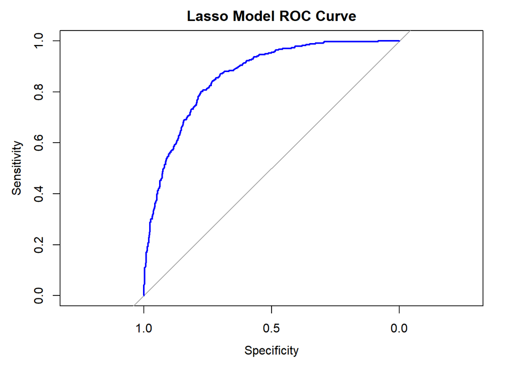

```r
# Construct x (predictor matrix) and y (response vector) on test data
x.test <- model.matrix(Status_bin ~ . - Status, data = test_set)[, -1]
y.test <- test_set$Status_bin

# Generate predictions
lasso.pred <- predict(lasso.mod, s = bestlambda, newx = x.test, type = "response")

# Convert probability to predicted category (0 or 1)
lasso.pred.class <- ifelse(lasso.pred > 0.5, 1, 0)

#Draw ROC curve and calculate AUC
roc_obj <- roc(y.test, as.vector(lasso.pred))
plot(roc_obj, main = "Lasso Model ROC Curve", col = "blue")
```

```r
auc(roc_obj)
```

```
## Area under the curve: 0.8611
```

The **AUC** of Logistic regression with lasso regularization using all Lasso-selected variables is **0.8611**

```r
# Build an improved predictor matrix for the model
x_new <- model.matrix(Status_bin ~ Gender + SeniorCitizen + Partner + Tenure +
                        MultipleLines + InternetService + OnlineSecurity +
                        StreamingMovies + Contract + PaperlessBilling +
                        PaymentMethod + MonthlyCharges + TotalCharges +
                        IsLongTermCustomer + IsHighCharge +
                        IsHighValueCustomer + IsContractLocked,
                      data = training_set)[, -1]

# Build response vector
y_new <- training_set$Status_bin

# Set lambda grid
grid1 <- 10 ^ seq(2, -4, length = 100)

# Fit Lasso regression model across the grid of lambda values
lasso.mod1 <- glmnet(x_new,y_new,alpha = 1, lambda = grid1, family ="binomial")
```

```r
# Cross validation again to find the optimal lambda
set.seed(1731)
cv.lasso.new <- cv.glmnet(x_new, y_new, alpha = 1, lambda = grid1, family = "binomial")

# Extract the best lambda
bestlambda_new <- cv.lasso.new$lambda.min
```

```r
# Extract coefficients at the best lambda
lasso.coef1 <- predict(cv.lasso.new, type = "coefficients", s= bestlambda_new)
```

```r
# Perform the same processing on the test set
x_test_new <- model.matrix(Status_bin ~ Gender + SeniorCitizen + Partner + Tenure +
                             MultipleLines + InternetService + OnlineSecurity +
                             StreamingMovies + Contract + PaperlessBilling +
                             PaymentMethod + MonthlyCharges + TotalCharges +
                             IsLongTermCustomer + IsHighCharge +
                             IsHighValueCustomer + IsContractLocked,
                           data = test_set)[, -1]
y_test <- test_set$Status_bin
```

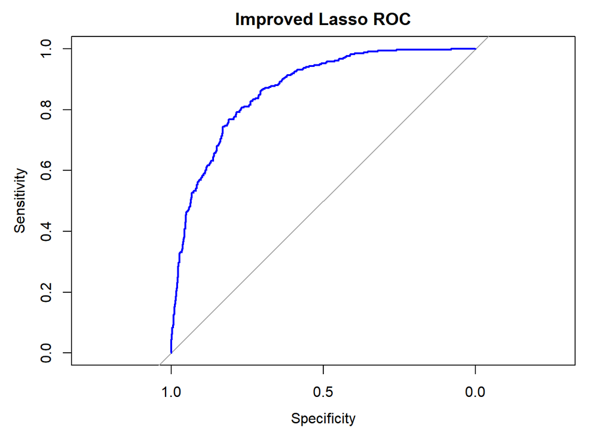

```r
# Perform the same processing on the test set
lasso_pred_new <- predict(cv.lasso.new, s = bestlambda_new, newx = x_test_new, type = "response")

# Convert probability to predicted category(0 or 1)
lasso.pred.class1 <- ifelse(lasso_pred_new > 0.5, 1, 0)

# Draw ROC curve and calculate AUC
roc_obj_new <- roc(y_test, as.vector(lasso_pred_new))
plot(roc_obj_new, main = "Improved Lasso ROC", col = "blue")
```

```r
auc(roc_obj_new)
```

```
## Area under the curve: 0.8658
```

The **AUC** of Logistic regression with lasso regularization using variables selected by 4.2.2 is **0.8658**, better than the outcome on first attempt

#### 4.2.3 Logistic regresion variables selection: Variable preparation and first attempt

While several engineered variables such as **HasFullService**, **ServiceCount**, and **IsContractLocked** were introduced to enhance interpretability, some of them caused multicollinearity or offered redundant information already captured by core features such as **Contract**, **InternetService**, and **Tenure**.So in the logistic regression section, we manually select variables

```r
logit_model1 <- glm(Status_bin ~ Tenure + InternetService  + Contract + PaperlessBilling +
      PaymentMethod + TotalCharges + IsLongTermCustomer,
    data = training_set, family = "binomial")
```

The plot below shows the logistic regression results based on the selected variables.

```r
# view the summary of model
summary(logit_model1)
```

```
##
## Call:
## glm(formula = Status_bin ~ Tenure + InternetService + Contract +
##     PaperlessBilling + PaymentMethod + TotalCharges + IsLongTermCustomer,
##     family = "binomial", data = training_set)
##
## Coefficients:
##                                        Estimate Std. Error z value Pr(>|z|)
## (Intercept)                          -5.222e-01  1.353e-01  -3.859 0.000114 ***
## Tenure                               -3.931e-02  7.522e-03  -5.226 1.73e-07 ***
## InternetServiceFiber optic            9.518e-01  1.036e-01   9.191  < 2e-16 ***
## InternetServiceNo                    -8.039e-01  1.457e-01  -5.519 3.41e-08 ***
## ContractOne year                     -7.704e-01  1.212e-01  -6.358 2.04e-10 ***
## ContractTwo year                     -1.652e+00  1.964e-01  -8.413  < 2e-16 ***
## PaperlessBillingYes                   3.971e-01  8.462e-02   4.692 2.70e-06 ***
## PaymentMethodCredit card (automatic) -1.277e-01  1.305e-01  -0.979 0.327591
## PaymentMethodElectronic check         3.816e-01  1.079e-01   3.535 0.000408 ***
## PaymentMethodMailed check            -7.438e-02  1.318e-01  -0.564 0.572532
## TotalCharges                          2.084e-04  7.053e-05   2.955 0.003129 **
## IsLongTermCustomerYes                -4.724e-01  1.221e-01  -3.870 0.000109 ***
## ---
## Signif. codes:  0 '***' 0.001 '**' 0.01 '*' 0.05 '.' 0.1 ' ' 1
##
## (Dispersion parameter for binomial family taken to be 1)
##
##     Null deviance: 6055.3  on 5198  degrees of freedom
## Residual deviance: 4415.0  on 5187  degrees of freedom
## AIC: 4439
##
## Number of Fisher Scoring iterations: 6
```

Most of the selected variables are **statistically significant (p < 0.05)**, indicating that they have a meaningful relationship with churn.

However, two variables — **PaymentMethod: Credit card (automatic)** and **PaymentMethod: Mailed check** — did **not reach statistical significance** in this model.

To ensure that these results are not influenced by **multicollinearity** (i.e., when predictors are too closely related), we will conduct a **Variance Inflation Factor (VIF) analysis** in the following steps.

The plot below shows the **ROC curve** for the logistic regression model. This curve helps evaluate the model’s **classification performance** by visualizing the trade-off between **sensitivity (true positive rate)** and **specificity (true negative rate)** across different thresholds.

A model with strong predictive ability will have a curve that bends sharply toward the top-left corner, indicating high sensitivity and specificity.

We will also calculate the **AUC (Area Under the Curve)** as a summary metric: the closer the AUC is to 1, the better the model performs.

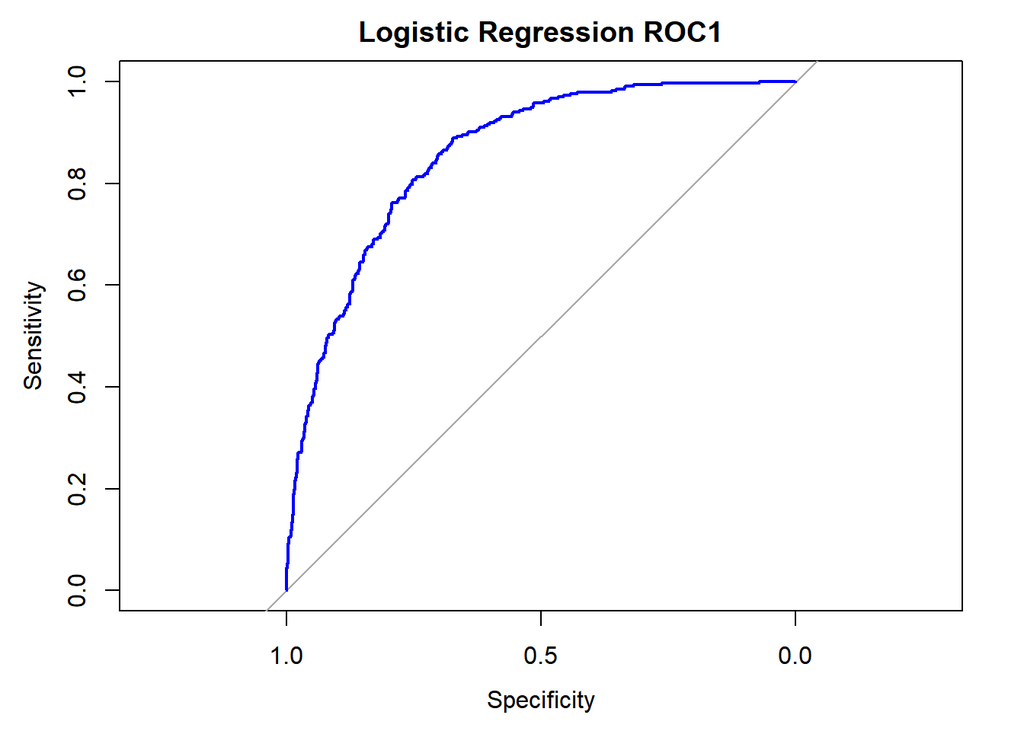

```r
# Predicted Probability
logit_prob0 <- predict(logit_model1, newdata = test_set, type = "response")

# ROC and AUC
roc_logit0 <- roc(test_set$Status_bin, logit_prob0)
plot(roc_logit0, main = "Logistic Regression ROC1",col = "blue")
```

```r
auc(roc_logit0)
```

```
## Area under the curve: 0.8567
```

The **AUC** of Logistic regression of first attempt is **0.8567**.

To assess **potential multicollinearity** among predictors, we examined the **Variance Inflation Factor (VIF)** values for all variables used in the logistic regression model, as shown below.

```r
# check VIF of all variables
vif(logit_model1)
```

```
##                         GVIF Df GVIF^(1/(2*Df))
## Tenure             18.459139  1        4.296410
## InternetService     1.969256  2        1.184610
## Contract            1.585404  2        1.122109
## PaperlessBilling    1.105111  1        1.051242
## PaymentMethod       1.363877  3        1.053083
## TotalCharges       16.274666  1        4.034187
## IsLongTermCustomer  2.628013  1        1.621115
```

Although the model achieves a high AUC, we aimed to further **improve its stability and interpretability** by addressing multicollinearity issues.

A **GVIF (Generalized Variance Inflation Factor)** analysis revealed that `Tenure` and `TotalCharges` were highly collinear (**GVIF > 5**). This is expected, since **TotalCharges is approximately the product of Tenure and MonthlyCharges**, meaning it contains redundant information.

To simplify the model and avoid redundancy, we decided to **retain `Tenure`** and remove `TotalCharges`. Tenure provides **a more direct business interpretation**, reflecting how long a customer has stayed with the company—a key indicator of loyalty and churn risk.

#### 4.2.3 Logistic regresion variables selection: attempt2: use all variables from 4.2.2 without “TotalCharges”

```r
logit_model2 <- glm(Status_bin ~ Tenure + InternetService  + Contract + PaperlessBilling +
      PaymentMethod + IsLongTermCustomer,
    data = training_set, family = "binomial")
```

Based on the previous **multicollinearity check**, we excluded **TotalCharges** and proceeded to rebuild the logistic regression model using all remaining variables selected in 4.2.2.

Below is the updated model specification and diagnostic review.

```r
# view the summary of model
summary(logit_model2)
```

```
##
## Call:
## glm(formula = Status_bin ~ Tenure + InternetService + Contract +
##     PaperlessBilling + PaymentMethod + IsLongTermCustomer, family = "binomial",
##     data = training_set)
##
## Coefficients:
##                                       Estimate Std. Error z value Pr(>|z|)
## (Intercept)                          -0.632775   0.130216  -4.859 1.18e-06 ***
## Tenure                               -0.019421   0.003126  -6.214 5.18e-10 ***
## InternetServiceFiber optic            1.112842   0.088617  12.558  < 2e-16 ***
## InternetServiceNo                    -0.858651   0.143186  -5.997 2.01e-09 ***
## ContractOne year                     -0.742473   0.120120  -6.181 6.37e-10 ***
## ContractTwo year                     -1.610793   0.194515  -8.281  < 2e-16 ***
## PaperlessBillingYes                   0.404092   0.084560   4.779 1.76e-06 ***
## PaymentMethodCredit card (automatic) -0.119005   0.130366  -0.913 0.361319
## PaymentMethodElectronic check         0.389272   0.107983   3.605 0.000312 ***
## PaymentMethodMailed check            -0.046425   0.131183  -0.354 0.723417
## IsLongTermCustomerYes                -0.574140   0.117302  -4.895 9.85e-07 ***
## ---
## Signif. codes:  0 '***' 0.001 '**' 0.01 '*' 0.05 '.' 0.1 ' ' 1
##
## (Dispersion parameter for binomial family taken to be 1)
##
##     Null deviance: 6055.3  on 5198  degrees of freedom
## Residual deviance: 4424.2  on 5188  degrees of freedom
## AIC: 4446.2
##
## Number of Fisher Scoring iterations: 6
```

Most of the selected variables are **statistically significant (p < 0.05)**, indicating they have a meaningful relationship with customer churn.

However, two variables — **PaymentMethod: Credit card (automatic)** and **PaymentMethod: Mailed check** — did **not reach statistical significance**, suggesting they may not contribute meaningfully to the prediction in this model.

```r
# check VIF of all variables again
vif(logit_model2)
```

```
##                        GVIF Df GVIF^(1/(2*Df))
## Tenure             3.159110  1        1.777389
## InternetService    1.370950  2        1.082070
## Contract           1.560673  2        1.117707
## PaperlessBilling   1.102486  1        1.049994
## PaymentMethod      1.348871  3        1.051143
## IsLongTermCustomer 2.403463  1        1.550311
```

All **VIF (Variance Inflation Factor)** values are below the commonly accepted threshold of **5**, indicating that **multicollinearity is not a concern** among the selected variables.

This means that the predictors in our model are not excessively correlated with each other, helping ensure that the estimated effects of each variable are **stable and interpretable**.

The plot below shows the ROC curve for the **attempt2**, helping us evaluate its **classification performance** in terms of sensitivity and specificity.

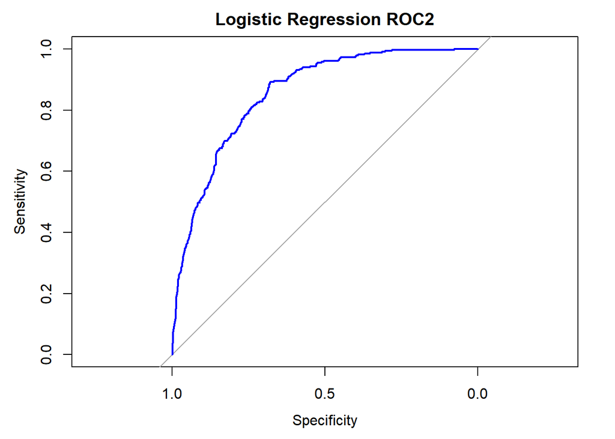

```r
# Predicted Probability
logit_prob1 <- predict(logit_model2, newdata = test_set, type = "response")

# ROC and AUC
roc_logit1 <- roc(test_set$Status_bin, logit_prob1)
plot(roc_logit1, main = "Logistic Regression ROC2",col = "blue")
```

```r
auc(roc_logit1)
```

```
## Area under the curve: 0.8553
```

#### 4.2.4 Logistic regresion variables selection: attempt3: use significant variables from 4.2.3

**To further refine the model**, we included only the variables that were statistically significant in the previous attempt, as shown below.

```r
logit_model3 <- glm(Status_bin ~ Tenure + InternetService  + Contract + PaperlessBilling +
       + IsLongTermCustomer,
    data = training_set, family = "binomial")
```

```r
# view the summary of model
summary(logit_model3)
```

```
##
## Call:
## glm(formula = Status_bin ~ Tenure + InternetService + Contract +
##     PaperlessBilling + +IsLongTermCustomer, family = "binomial",
##     data = training_set)
##
## Coefficients:
##                            Estimate Std. Error z value Pr(>|z|)
## (Intercept)                -0.50092    0.09070  -5.523 3.33e-08 ***
## Tenure                     -0.02017    0.00309  -6.527 6.71e-11 ***
## InternetServiceFiber optic  1.19869    0.08656  13.848  < 2e-16 ***
## InternetServiceNo          -0.97595    0.14010  -6.966 3.26e-12 ***
## ContractOne year           -0.80856    0.11923  -6.782 1.19e-11 ***
## ContractTwo year           -1.70677    0.19348  -8.821  < 2e-16 ***
## PaperlessBillingYes         0.43283    0.08379   5.165 2.40e-07 ***
## IsLongTermCustomerYes      -0.58890    0.11654  -5.053 4.34e-07 ***
## ---
## Signif. codes:  0 '***' 0.001 '**' 0.01 '*' 0.05 '.' 0.1 ' ' 1
##
## (Dispersion parameter for binomial family taken to be 1)
##
##     Null deviance: 6055.3  on 5198  degrees of freedom
## Residual deviance: 4456.2  on 5191  degrees of freedom
## AIC: 4472.2
##
## Number of Fisher Scoring iterations: 6
```

**All selected predictors remain highly statistically significant (p < 0.001)**, indicating that they have **strong and consistent effects** on the likelihood of customer churn.

This high level of significance increases our confidence in the model’s findings, suggesting that the included variables are truly meaningful in explaining customer behavior.

The plot below shows the ROC curve for the **attempt3**, helping us evaluate its **classification performance** in terms of sensitivity and specificity.

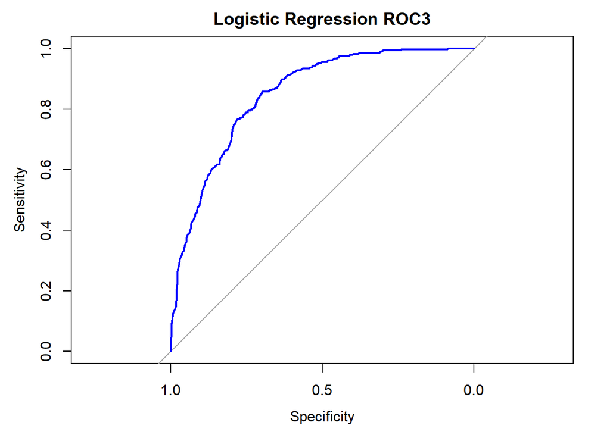

```r
# Predicted Probability
logit_prob2 <- predict(logit_model3, newdata = test_set, type = "response")

# ROC and AUC
roc_logit2 <- roc(test_set$Status_bin, logit_prob2)
plot(roc_logit2, main = "Logistic Regression ROC3",col = "blue")
```

```r
auc(roc_logit2)
```

```
## Area under the curve: 0.8497
```

The **AUC** of Logistic regression of third attempt is **0.8497**.

Conclusion

**If the goal is to maximize predictive performance (AUC)**, we recommend using the **Lasso logistic regression model developed in Section 4.2.2**.  
This model uses **feature selection and regularization**, achieving the **highest AUC (0.8658)** among all logistic regression models tested.

**However, if business interpretability is a key priority**, we suggest using the **standard logistic regression model from Section 4.2.3**.  
While its AUC is slightly lower (**0.8553**), this model avoids multicollinearity and provides **clear, interpretable relationships** between predictors and churn—making it more actionable for business decision-making.

### 4.3 For the model with the highest AUC, interpret each coefficient and provide guidance to the reader on how varying the different variables will influence customer behavior.

```r
# view the summary of model
summary(logit_model2)
```

```
##
## Call:
## glm(formula = Status_bin ~ Tenure + InternetService + Contract +
##     PaperlessBilling + PaymentMethod + IsLongTermCustomer, family = "binomial",
##     data = training_set)
##
## Coefficients:
##                                       Estimate Std. Error z value Pr(>|z|)
## (Intercept)                          -0.632775   0.130216  -4.859 1.18e-06 ***
## Tenure                               -0.019421   0.003126  -6.214 5.18e-10 ***
## InternetServiceFiber optic            1.112842   0.088617  12.558  < 2e-16 ***
## InternetServiceNo                    -0.858651   0.143186  -5.997 2.01e-09 ***
## ContractOne year                     -0.742473   0.120120  -6.181 6.37e-10 ***
## ContractTwo year                     -1.610793   0.194515  -8.281  < 2e-16 ***
## PaperlessBillingYes                   0.404092   0.084560   4.779 1.76e-06 ***
## PaymentMethodCredit card (automatic) -0.119005   0.130366  -0.913 0.361319
## PaymentMethodElectronic check         0.389272   0.107983   3.605 0.000312 ***
## PaymentMethodMailed check            -0.046425   0.131183  -0.354 0.723417
## IsLongTermCustomerYes                -0.574140   0.117302  -4.895 9.85e-07 ***
## ---
## Signif. codes:  0 '***' 0.001 '**' 0.01 '*' 0.05 '.' 0.1 ' ' 1
##
## (Dispersion parameter for binomial family taken to be 1)
##
##     Null deviance: 6055.3  on 5198  degrees of freedom
## Residual deviance: 4424.2  on 5188  degrees of freedom
## AIC: 4446.2
##
## Number of Fisher Scoring iterations: 6
```

Display the Model Output

Model Significance (Chi-squared Test)

The overall logistic regression model is **statistically significant (p < 0.001)** based on the Chi-squared test comparing the **null deviance (6055.3)** to the **residual deviance (4424.2)**.  
This result suggests that **at least one predictor variable is significantly associated with customer churn**.

Non-Significant Predictors (p > 0.05)

- **PaymentMethod: Credit card (automatic)** → Not significantly different from baseline.
- **PaymentMethod: Mailed check** → Not significantly different from baseline.

### 4.4 Try different thresholds to identify the threshold with the highest prediction accuracy on the test set.

**To finalize our prediction model**, we evaluate different classification thresholds and select the one that yields the **highest prediction accuracy on the test set.**

```r
# Predicting probabilities on test_det using a model
pred_prob <- predict(logit_model2, newdata = test_set, type = "response")

# Create different threshold vectors
thresholds <- seq(0.1, 0.9, by = 0.05)

# Initialization result storage box
accuracy_results <- data.frame(Threshold = thresholds, Accuracy = NA)

# Traverse all thresholds and calculate accuracy
for (i in seq_along(thresholds)) {
  threshold <- thresholds[i]
  pred_class <- ifelse(pred_prob > threshold, 1, 0)
  accuracy <- mean(pred_class == test_set$Status_bin)
  accuracy_results$Accuracy[i] <- accuracy
}

# Print the optimal threshold
best_threshold <- accuracy_results[which.max(accuracy_results$Accuracy), ]
best_threshold
```

```
##   Threshold  Accuracy
## 9       0.5 0.8053846
```

Visualize the accuracy at each threshold

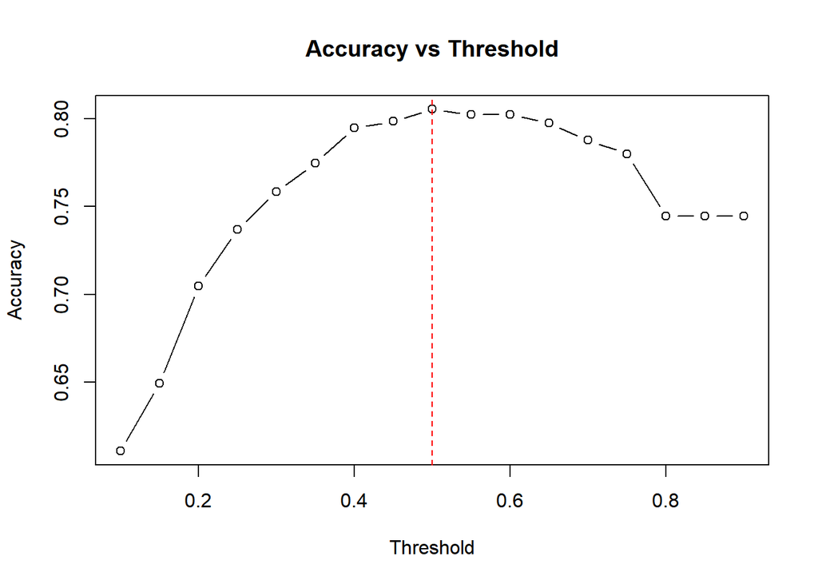

```r
# Plot the accuracy at each threshold
plot(accuracy_results$Threshold, accuracy_results$Accuracy, type = "b",
     xlab = "Threshold", ylab = "Accuracy", main = "Accuracy vs Threshold")
abline(v = best_threshold$Threshold, col = "red", lty = 2)
```

The threshold of the **highest prediction accuracy** on the test set is **0.5**

## 5. Naive Bayes

### 5.1 Use the training set to build a Naive Bayes model to predict the probability for losing a customer.

**To begin Naive Bayes modeling**, we first identify all categorical variables in the cleaned training dataset, as these will be used as inputs for the classifier.

```r
# View variable names of all factor types
categorical_vars <- names(Filter(is.factor, Model_Building_Data_cleaned))
categorical_vars
```

```
##  [1] "Gender"              "SeniorCitizen"       "Partner"
##  [4] "Dependents"          "PhoneService"        "MultipleLines"
##  [7] "InternetService"     "OnlineSecurity"      "DeviceProtection"
## [10] "StreamingMovies"     "Contract"            "PaperlessBilling"
## [13] "PaymentMethod"       "Status"              "IsLongTermCustomer"
## [16] "IsHighCharge"        "IsHighValueCustomer" "IsContractLocked"
## [19] "HasFullService"      "IsTechComfortable"   "ServiceCountGroup"
```

**To examine potential dependency between categorical variables**, we conduct pairwise **Chi-squared tests of independence.** This helps us identify any **redundant relationships** that may affect Naive Bayes assumptions or model clarity.

```r
# Select all factor variables except for Status
vars_for_independence_test <- categorical_vars[categorical_vars != "Status"]

# Create an empty result table
chi_results_df <- data.frame(
  Var1 = character(),
  Var2 = character(),
  p_value = numeric(),
  stringsAsFactors = FALSE
)

# Traverse combinations and save significant results
for (i in 1:(length(vars_for_independence_test) - 1)) {
  for (j in (i + 1):length(vars_for_independence_test)) {
    var1 <- vars_for_independence_test[i]
    var2 <- vars_for_independence_test[j]

    tbl <- table(Model_Building_Data_cleaned[[var1]], Model_Building_Data_cleaned[[var2]])

    if (all(dim(tbl) > 1)) {
      test <- suppressWarnings(chisq.test(tbl))
      if (test$p.value < 0.05) {
        chi_results_df <- rbind(chi_results_df, data.frame(
          Var1 = var1,
          Var2 = var2,
          p_value = round(test$p.value, 4),
          stringsAsFactors = FALSE
        ))
      }
    }
  }
}

# Use DT to display interactive tables that can be flipped through
datatable(chi_results_df, options = list(
  pageLength = 15,
  autoWidth = TRUE
))
```

|  | Var1 | Var2 | p_value |
| --- | --- | --- | --- |
| 1 | SeniorCitizen | Dependents | 0 |
| 2 | SeniorCitizen | MultipleLines | 0 |
| 3 | SeniorCitizen | InternetService | 0 |
| 4 | SeniorCitizen | OnlineSecurity | 0 |
| 5 | SeniorCitizen | DeviceProtection | 0 |
| 6 | SeniorCitizen | StreamingMovies | 0 |
| 7 | SeniorCitizen | Contract | 0 |
| 8 | SeniorCitizen | PaperlessBilling | 0 |
| 9 | SeniorCitizen | PaymentMethod | 0 |
| 10 | SeniorCitizen | IsHighCharge | 0 |

[output cut: 139 more lines]

##### 5.1.1 Model Assumptions and Limitations

Although the **Naive Bayes** classifier relies on the assumption of **conditional independence** among predictor variables, we conducted a series of **Chi-squared tests** to evaluate this assumption.

The **Chi-squared test** assesses whether two categorical variables are **statistically independent**.  
A low p-value (typically < 0.05) indicates that the variables are **dependent**, thus violating the Naive Bayes assumption.

Our results showed that many variable pairs produced **extremely low p-values**, suggesting **strong interdependencies** and clear violations of the independence assumption.

Nevertheless, we included **Naive Bayes** in our modeling pipeline as a **baseline classifier**.  
This is justified by its:

- **Computational efficiency**
- **Simplicity**
- And **surprisingly strong empirical performance**, even when the independence assumption is violated in practice.

##### 5.1.2 Build Naive Bayes Model with all categorical independent variables

```r
# Redefine Status to put 'Left' first (becoming a positive class)
training_set$Status <- relevel(training_set$Status, ref = "Left")
test_set$Status <- relevel(test_set$Status, ref = "Left")


# Extract all factor type variables from the training set
categorical_vars_train <- names(Filter(is.factor, training_set))

# Remove the target variable 'Status'
vars_for_NB_model <- setdiff(categorical_vars_train, "Status")

# Splicing formula
nb_formula <- as.formula(paste("Status ~", paste(vars_for_NB_model, collapse = " + ")))

# Create the Naive Bayes Model
NB_model <- naiveBayes(nb_formula, Model_Building_Data_cleaned, laplace = 0.01)
```

**To further illustrate how the Naive Bayes model estimates churn risk**, we display the predicted probabilities for a few individual customers below:

```r
# Predicting the probability of churn
NB_pred_prob <- predict(NB_model, newdata = test_set, type = "raw")

# Extract the probability of predicting as' Left '
churn_probs <- NB_pred_prob[, "Left"]

# Check the probability of losing the first few customers
head(churn_probs)
```

```
## [1] 0.9584728 0.2320168 0.9743960 0.9945036 0.9887152 0.9901620
```

The Naive Bayes model was used to estimate the **probability** that **each customer in the test set would churn.** Instead of simply predicting whether a customer will churn or not, the model outputs a **probability score** for each customer belonging to the **“Left”** class. These probabilities represent the model’s confidence that a customer is likely to leave.

For example:

The **first customer** has a **95.8%** chance of churning, indicating **very high risk**.

The **second customer** has only a **23.2%** chance of churning, indicating **low risk**.

**In addition to individual-level predictions**, we also calculate the **average churn probability across all test customers** to assess the overall risk profile of the customer base.

```r
# Average predicted churn probability (overall average churn rate)
mean_churn_prob <- mean(NB_pred_prob[, "Left"])
print(mean_churn_prob)
```

```
## [1] 0.3928178
```

According to the Naive Bayes model’s prediction of test set customers, there is an **average probability of 39.3% for each customer to be lost**. This indicates that approximately **40% of the customers in the entire customer base are at risk of churn** as determined by the model.

### 5.2 Try different combinations of variables and arrive at the model that maximizes AUC for the ROC plots.

#### 5.2.1 First attempt, using all categorical independent variables

**To evaluate the performance of the Naive Bayes model using all categorical predictors**, we plotted the ROC curve below. This allows us to assess how well the model distinguishes between churned and retained customers.

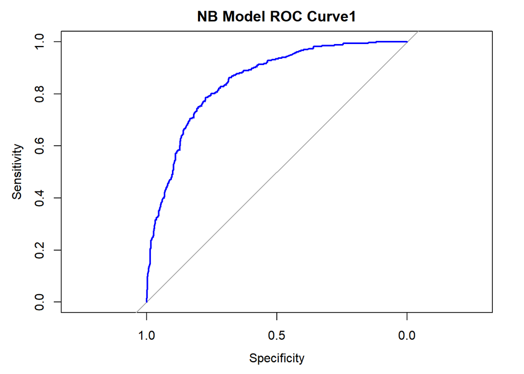

```r
# Generate predictions
NB.pred1 <- predict(NB_model, newdata = test_set, type = "raw")

churn_probs <- NB.pred1[, "Left"]



# Convert probability to predicted category (0 or 1)
NB.pred.class <- ifelse(churn_probs > 0.5, 1, 0)

#Draw ROC curve and calculate AUC
roc_obj_NB1 <- roc_obj_NB1 <- roc(test_set$Status_bin, churn_probs)
plot(roc_obj_NB1, main = "NB Model ROC Curve1", col = "blue")
```

```r
auc(roc_obj_NB1)
```

```
## Area under the curve: 0.8487
```

The **AUC** OF first attempt is **0.8487**.

#### 5.2.1 Second attempt, using all categorical independent variables without “IsHighCharge”

The plot below shows the ROC curve for the **attempt2**, helping us evaluate its **classification performance** in terms of sensitivity and specificity.

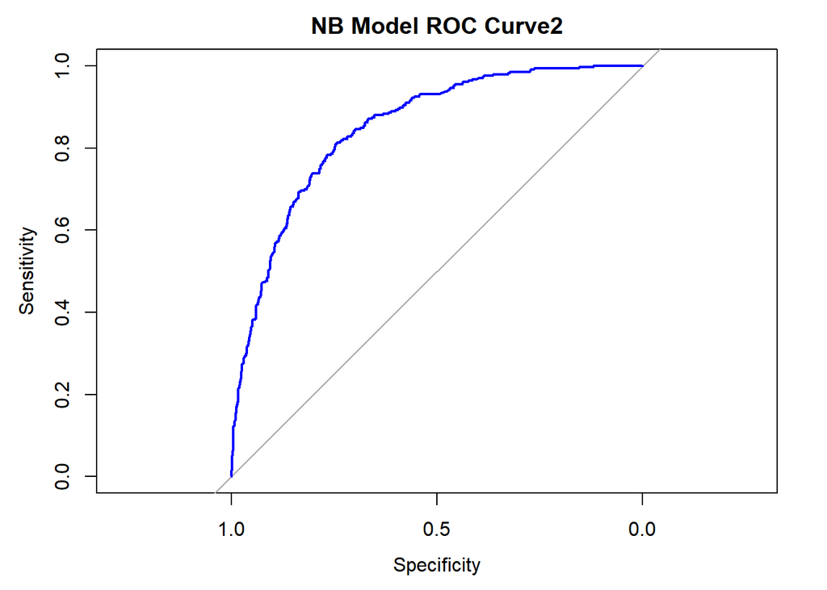

```r
NB_model2 <- naiveBayes(Status ~  Gender + SeniorCitizen + Partner + Dependents + PhoneService +  MultipleLines + InternetService + OnlineSecurity+
                          DeviceProtection + StreamingMovies  + Contract  +  PaperlessBilling  +  PaymentMethod + IsLongTermCustomer +
                          IsHighValueCustomer+ IsContractLocked + HasFullService + IsTechComfortable + ServiceCountGroup, Model_Building_Data_cleaned, laplace = 0.01)

# Generate predictions
NB.pred3 <- predict(NB_model2, newdata = test_set, type = "raw")

churn_probs2 <- NB.pred3[, "Left"]

# Convert probability to predicted category (0 or 1)
NB.pred.class2 <- ifelse(churn_probs2 > 0.5, 1, 0)



#Draw ROC curve and calculate AUC
roc_obj_NB3 <- roc(test_set$Status_bin, churn_probs2)
plot(roc_obj_NB3, main = "NB Model ROC Curve2", col = "blue")
```

```r
auc(roc_obj_NB3)
```

```
## Area under the curve: 0.8493
```

The **AUC** OF second attempt is **0.8493**.

#### 5.2.1 Third attempt, using all categorical independent variables without “IsTechComfortable”

The plot below shows the ROC curve for the **attempt3**, helping us evaluate its **classification performance** in terms of sensitivity and specificity.

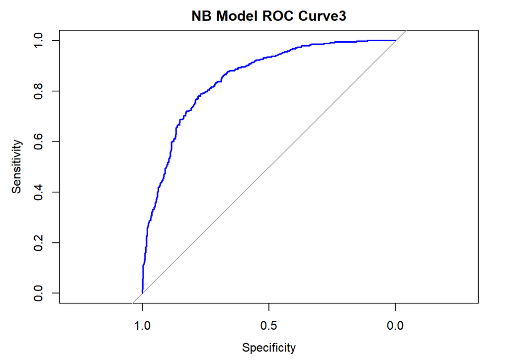

```r
NB_model3 <- naiveBayes(Status ~  Gender + SeniorCitizen + Partner + Dependents + PhoneService +  MultipleLines + InternetService + OnlineSecurity+
                          DeviceProtection + StreamingMovies  + Contract  +  PaperlessBilling  +  PaymentMethod + IsLongTermCustomer + IsHighCharge +
                          IsHighValueCustomer+ IsContractLocked + HasFullService + ServiceCountGroup, Model_Building_Data_cleaned, laplace = 0.01)

# Generate predictions
NB.pred4 <- predict(NB_model3, newdata = test_set, type = "raw")

churn_probs3 <- NB.pred4[, "Left"]

# Convert probability to predicted category (0 or 1)
NB.pred.class3 <- ifelse(churn_probs3 > 0.5, 1, 0)



#Draw ROC curve and calculate AUC
roc_obj_NB4 <- roc(test_set$Status_bin, churn_probs3)
plot(roc_obj_NB4, main = "NB Model ROC Curve3", col = "blue")
```

```r
auc(roc_obj_NB4)
```

```
## Area under the curve: 0.8495
```

### 5.3 For the model with the highest AUC, try different thresholds to identify the threshold with the highest prediction accuracy on the test set.

**To further fine-tune the model with the highest AUC**, we tested a range of probability thresholds to identify which one yields the best classification accuracy on the test set. The following result shows the optimal threshold and corresponding accuracy.

```r
# Predicting probabilities on test_det using a model
pred_prob_NB_best <- predict(NB_model3, newdata = test_set, type = "raw")
churn_probs_best <- pred_prob_NB_best[, "Left"]

# Create different threshold vectors
thresholds_NB <- seq(0.1, 0.95, by = 0.05)

# Initialize result storage
accuracy_results_NB <- data.frame(Threshold = thresholds_NB, Accuracy_NB = NA)

# Loop through each threshold and calculate accuracy
for (i in seq_along(thresholds_NB)) {
  threshold <- thresholds_NB[i]
  pred_class_NB <- ifelse(churn_probs_best > threshold, 1, 0)
  accuracy_NB <- mean(pred_class_NB == test_set$Status_bin)
  accuracy_results_NB$Accuracy_NB[i] <- accuracy_NB
}

# Find the best threshold
best_threshold_NB <- accuracy_results_NB[which.max(accuracy_results_NB$Accuracy_NB), ]
best_threshold_NB
```

```
##    Threshold Accuracy_NB
## 17       0.9   0.8076923
```

Visualize the accuracy at each threshold

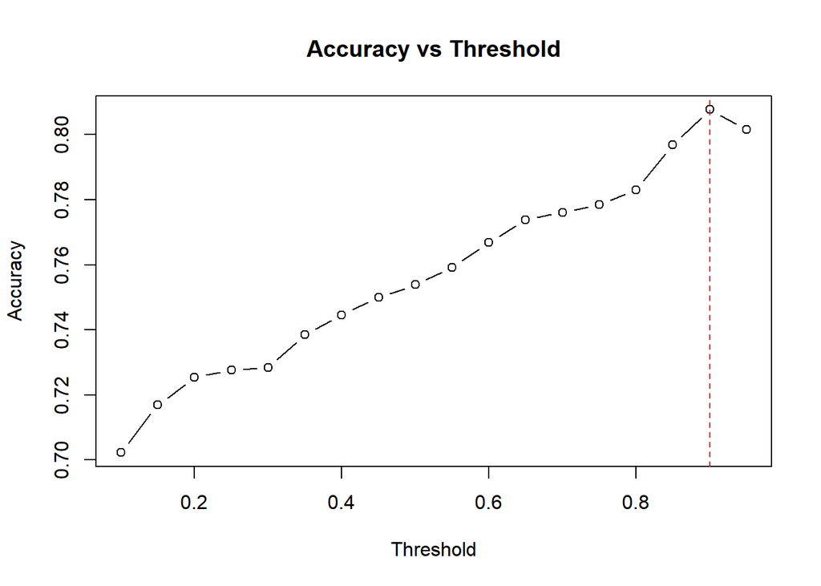

```r
# Plot accuracy vs threshold
plot(accuracy_results_NB$Threshold, accuracy_results_NB$Accuracy_NB, type = "b",
     xlab = "Threshold", ylab = "Accuracy", main = "Accuracy vs Threshold")
abline(v = best_threshold_NB$Threshold, col = "red", lty = 2)
```

The threshold of the **highest prediction accuracy** on the test set is **0.9**.

## 6. Linear Discriminant Analysis

### 6.1 Use the training set to build a model using Linear Discriminant Analysis to predict the probability for losing a customer.

#### 6.1.1 Assumption Check for LDA: Homogeneity of Covariance Matrices

Before fitting a **Linear Discriminant Analysis (LDA)** model, we examined one of its key assumptions:  
the **homogeneity of covariance matrices** across classes.  
This means that the **relationship between predictors** should have a similar variance-covariance structure for both **churned** and **retained** customers.

LDA relies on this assumption because it builds its classification rule by pooling all group-specific covariances into a **single shared covariance matrix**.

To test this assumption, we conducted **Box’s M test** using two key continuous predictors:

- `Tenure`
- `MonthlyCharges`

```r
# Keep only two main continuous variables
numeric_vars2 <- training_set %>% dplyr::select(Tenure, MonthlyCharges)

# Perform Box's M test
boxM(numeric_vars2, grouping = training_set$Status)
```

```
##
##  Box's M-test for Homogeneity of Covariance Matrices
##
## data:  numeric_vars2
## Chi-Sq (approx.) = 218.56, df = 3, p-value < 2.2e-16
```

Rationale for Box’s M Test Variable Selection

We selected only `Tenure` and `MonthlyCharges` for the **Box’s M test** due to the following reasons:

- These are the **primary numeric predictors** used in the LDA model.
- Adding variables like `TotalCharges` or `ServiceCount` caused **multicollinearity** and **singular covariance matrices**, resulting in unstable or invalid test statistics (e.g., Chi-Sq = NaN).
- Most other predictors are **categorical or binary**, which are not suitable for this test and may distort results.

Assumption Testing Scope

We **did not test** other LDA assumptions (e.g., multivariate normality, absence of multicollinearity) because:

- LDA is **robust** to mild departures from normality in practice.
- **Multicollinearity** was already handled during feature engineering and variable selection.
- Our main objective is **model comparison based on performance metrics** (e.g., AUC), rather than strict inferential assumptions.

Box’s M Test Result

- **Chi-squared ≈ 218.56**, **p-value < 0.001**
- Indicates that the **homogeneity of covariance matrices assumption is violated**
- Therefore, **QDA may be more appropriate** under strict statistical assumptions.

Nevertheless, we proceed with LDA for comparison, given its interpretability and value as a benchmark model.

#### 6.1.2 Linear Discriminant Analysis (LDA) Modeling

LDA Variable Selection

These variables were selected based on the following criteria:

**Business Relevance**:  
Variables like **tenure**, **contract type**, and **service subscriptions** are intuitively linked to customer loyalty and churn risk. Including these features enhances the model’s real-world interpretability.

**Multicollinearity Avoidance**:  
We excluded variables that caused **perfect or near-perfect multicollinearity**, such as engineered flags or redundant dummy categories (e.g., `OnlineSecurityNo internet service`, `IsContractLockedYes`).  
This ensures the model remains **numerically stable** and avoids **rank deficiency** issues.

```r
# Establish LDA model
LDA_model1 <- lda(Status ~ SeniorCitizen + Partner + Dependents +
                                 PhoneService + InternetService +
                                 Contract + PaperlessBilling + PaymentMethod +
                                 Tenure + MonthlyCharges,
                                 data = training_set)
```

**After building the LDA model using the selected variables**, we applied it to the test set to generate predicted probabilities of customer churn. The model outputs the likelihood that each customer will belong to the “Left” class, which we interpret as the risk of churn. The results below illustrate the model’s predictions for a sample of test customers.

```r
# Predict using test data
LDA_pred_prob <- predict(LDA_model1, newdata = test_set)

# Extract probability of being classified as "Left"
churn_probs_LDA <- LDA_pred_prob$posterior[, "Left"]

# Preview first few churn probabilities
head(churn_probs_LDA)
```

```
##         9        19        20        37        51        54
## 0.6032759 0.1882343 0.6490334 0.7647087 0.5587028 0.6825233
```

The LDA model was used to estimate the probability that each customer in the test set would churn. Instead of simply predicting whether a customer will churn or not, the model outputs a **probability score** for each customer belonging to the **“Left”** class. These probabilities represent the model’s confidence that a customer is likely to leave.

For example:

The **first customer** has a **60.3%** chance of churning, indicating **relative high risk**.

The **second customer** has only a **18.8%** chance of churning, indicating **low risk**.

**To better understand the overall risk level identified by the LDA model**, we computed the average predicted probability of churn across all customers in the test set. This average provides a high-level view of how much of the customer base is considered at risk according to the model’s predictions.

```r
# Average predicted churn probability (overall average churn rate)
mean_churn_prob_LDA <- mean(churn_probs_LDA)
mean_churn_prob_LDA
```

```
## [1] 0.2737424
```

According to the LDA model’s prediction of test set customers, there is an **average probability of 27.4% for each customer to be lost**. This indicates that approximately **28% of the customers in the entire customer base are at risk of churn** as determined by the model.

### 6.2 Try different combinations of variables and arrive at the model that maximizes AUC for the ROC plots.

#### 6.2.1 Fist attempt: Use all variables from 6.1.2

**To evaluate the performance of the LDA model more comprehensively**, we examined its Receiver Operating Characteristic (ROC) curve and calculated the Area Under the Curve (AUC). A higher AUC indicates better overall classification ability across various threshold settings.

```r
# Use model make prediction
LDA_pred_1 <- predict(LDA_model1, newdata = test_set)

# Extract probability of being classified as "Left"
churn_probs_1 <- LDA_pred_1$posterior[, "Left"]

# Draw ROC curve and calculate AUC
roc_obj_1 <- roc(test_set$Status, churn_probs_1,levels = c("Current", "Left"), direction = "<")
auc(roc_obj_1)
```

```
## Area under the curve: 0.8562
```

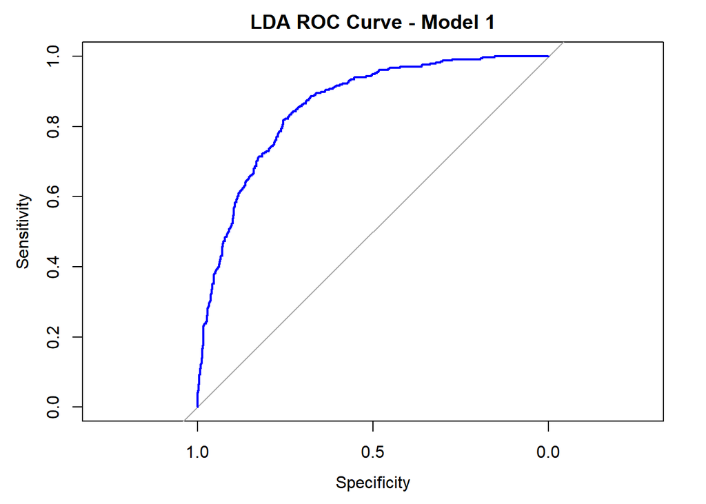

```r
plot(roc_obj_1, main = "LDA ROC Curve - Model 1", col = "blue")
```

The **AUC** Of first attempt is **0.8562**.

#### 6.2.2 Second attempt, using all categorical independent variables from 6.2.1 without “Partner”

The plot below shows the ROC curve for the **attempt2**, helping us evaluate its **classification performance** in terms of sensitivity and specificity.

```r
LDA_model_2 <- lda(Status ~  SeniorCitizen + Dependents +
                                 PhoneService + InternetService +
                                 Contract + PaperlessBilling + PaymentMethod +
                                 Tenure + MonthlyCharges, data = training_set)
# Generate predictions
LDA_pred_2 <- predict(LDA_model_2, newdata = test_set)

# Extract probability of being classified as "Left"
churn_probs_2 <- LDA_pred_2$posterior[, "Left"]
roc_obj_2 <- roc(test_set$Status, churn_probs_2,levels = c("Current", "Left"), direction = "<")

#Draw ROC curve and calculate AUC
auc(roc_obj_2)
```

```
## Area under the curve: 0.8566
```

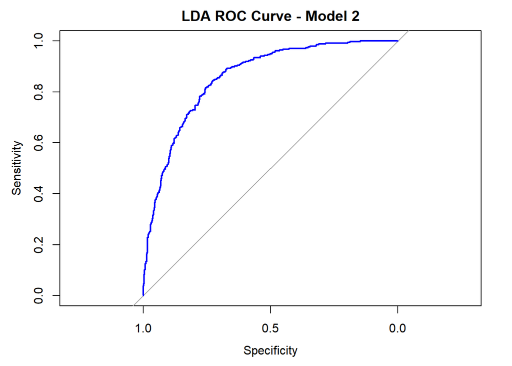

```r
plot(roc_obj_2, main = "LDA ROC Curve - Model 2", col = "blue")
```

The **AUC** Of second attempt is **0.8566**.

#### 6.2.2 Third attempt, using all categorical independent variables from 6.2.1 without “InternetService”

The plot below shows the ROC curve for the **attempt3**, helping us evaluate its **classification performance** in terms of sensitivity and specificity.

```r
LDA_model_3 <- lda(Status ~  SeniorCitizen + Partner + Dependents +
                                 PhoneService +
                                 Contract + PaperlessBilling + PaymentMethod +
                                 Tenure + MonthlyCharges, data = training_set)
# Generate predictions
LDA_pred_3 <- predict(LDA_model_3, newdata = test_set)

# Extract probability of being classified as "Left"
churn_probs_3 <- LDA_pred_3$posterior[, "Left"]
roc_obj_3 <- roc(test_set$Status, churn_probs_3,levels = c("Current", "Left"), direction = "<")

#Draw ROC curve and calculate AUC
auc(roc_obj_3)
```

```
## Area under the curve: 0.8575
```

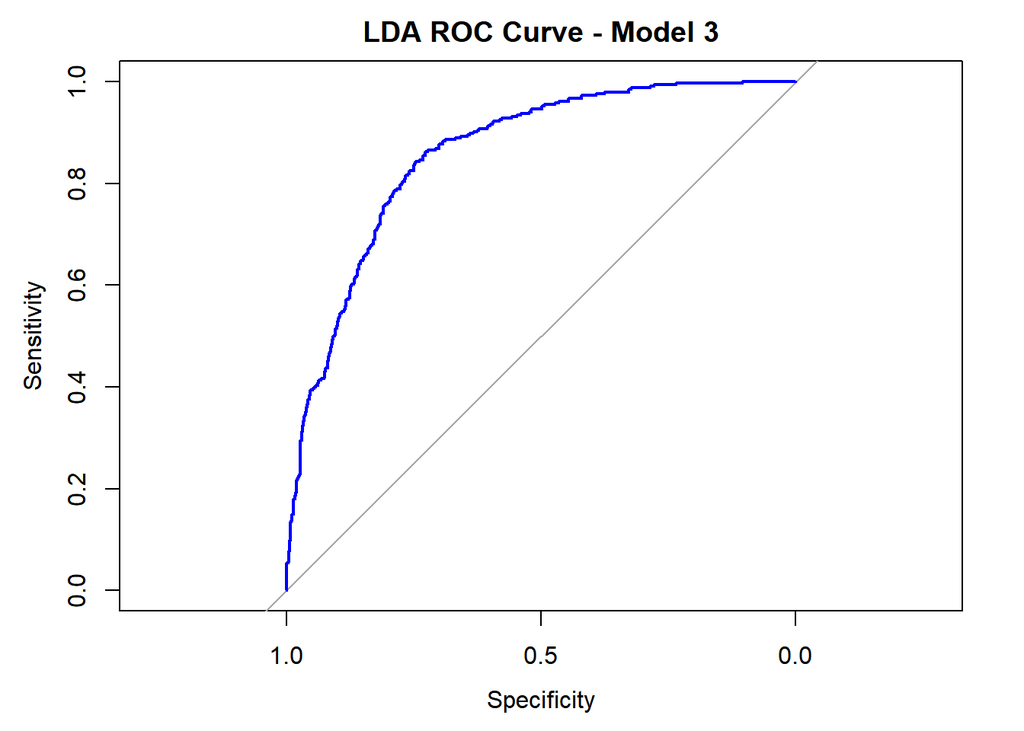

```r
plot(roc_obj_3, main = "LDA ROC Curve - Model 3", col = "blue")
```

After experimenting with several feature combinations, we found that removing the variable **InternetService**, which led to the highest **AUC (0.8575).**

### 6.3 For the model with the highest AUC, try different thresholds to identify the threshold with the highest prediction accuracy on the test set

**After identifying the best-performing LDA model based on AUC**, we proceeded to test different probability thresholds to find the one that yields the highest prediction accuracy on the test set. The result is shown below:

```r
# Predicting probabilities on test set using the best LDA model
pred_prob_LDA_best <- predict(LDA_model_3, newdata = test_set)
churn_probs_best_LDA <- pred_prob_LDA_best$posterior[, "Left"]

# Create different threshold vectors
thresholds_LDA <- seq(0.1, 0.95, by = 0.05)

# Initialize result storage
accuracy_results_LDA <- data.frame(Threshold = thresholds_LDA, Accuracy_LDA = NA)

# Loop through each threshold and calculate accuracy
for (i in seq_along(thresholds_LDA)) {
  threshold <- thresholds_LDA[i]
  pred_class_LDA <- ifelse(churn_probs_best_LDA > threshold, 1, 0)
  accuracy_LDA <- mean(pred_class_LDA == test_set$Status_bin)
  accuracy_results_LDA$Accuracy_LDA[i] <- accuracy_LDA
}

# Find the best threshold
best_threshold_LDA <- accuracy_results_LDA[which.max(accuracy_results_LDA$Accuracy_LDA), ]
best_threshold_LDA
```

```
##    Threshold Accuracy_LDA
## 11       0.6    0.8084615
```

Visualize the accuracy at each threshold

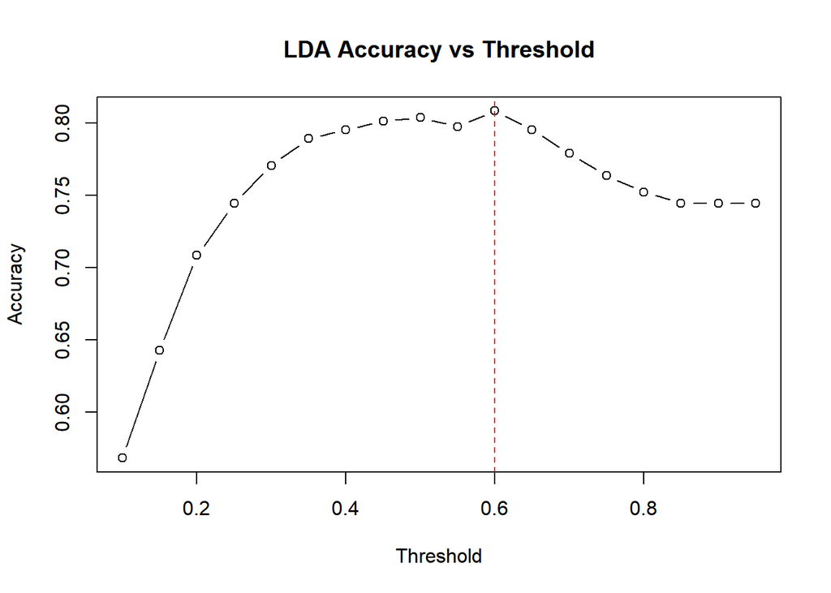

```r
# Plot accuracy vs threshold
plot(accuracy_results_LDA$Threshold, accuracy_results_LDA$Accuracy_LDA, type = "b",
     xlab = "Threshold", ylab = "Accuracy", main = "LDA Accuracy vs Threshold")
abline(v = best_threshold_LDA$Threshold, col = "red", lty = 2)
```

The threshold of the **highest prediction accuracy** on the test set is **0.6**.

## 7. Quadratic Discriminant Analysis

### 7,1 Use the training set to build a model using Quadratic Discriminant Analysis to predict the probability for losing a customer.

#### 7.1.1 Variable Selection Justification for QDA

To identify variables with **low variance, high imbalance, or redundancy**, we summarized all predictors for customers.

```r
# view the summary of Vriables
summary(training_set[training_set$Status == "Left", ])
```

```
##     Gender    SeniorCitizen Partner   Dependents     Tenure     PhoneService
##  Female:702   0:1040        No :889   No :1142   Min.   : 1.0   No : 124
##  Male  :697   1: 359        Yes:510   Yes: 257   1st Qu.: 2.0   Yes:1275
##                                                  Median :10.0
##                                                  Mean   :18.4
##                                                  3rd Qu.:30.0
##                                                  Max.   :72.0
##           MultipleLines    InternetService             OnlineSecurity
##  No              :640   DSL        :329    No                 :1091
##  No phone service:124   Fiber optic:988    No internet service:  82
##  Yes             :635   No         : 82    Yes                : 226
##
##
##
##             DeviceProtection            StreamingMovies           Contract
##  No                 :896     No                 :695    Month-to-month:1231
##  No internet service: 82     No internet service: 82    One year      : 129
##  Yes                :421     Yes                :622    Two year      :  39
##
##
##
##  PaperlessBilling                   PaymentMethod MonthlyCharges
##  No : 356         Bank transfer (automatic):194   Min.   : 18.85
##  Yes:1043         Credit card (automatic)  :170   1st Qu.: 59.70
##                   Electronic check         :804   Median : 79.90
##                   Mailed check             :231   Mean   : 75.11
##                                                   3rd Qu.: 94.53
##                                                   Max.   :118.35
##   TotalCharges         Status     IsLongTermCustomer IsHighCharge
##  Min.   :  18.85   Left   :1399   No :735            No :450
##  1st Qu.: 141.93   Current:   0   Yes:664            Yes:949
##  Median : 740.30
##  Mean   :1579.43
##  3rd Qu.:2416.32
##  Max.   :8684.80
##  IsHighValueCustomer IsContractLocked HasFullService IsTechComfortable
##  No :1196            No :1231         No :1323       No :654
##  Yes: 203            Yes: 168         Yes:  76       Yes:745
##
##
##
##
##   ServiceCount   ServiceCountGroup   Status_bin
##  Min.   :0.000   High:567          Min.   :1
##  1st Qu.:1.000   Low :832          1st Qu.:1
##  Median :2.000                     Median :1
##  Mean   :2.272                     Mean   :1
##  3rd Qu.:3.000                     3rd Qu.:1
##  Max.   :5.000                     Max.   :1
```

Final Variable Selection for QDA

Quadratic Discriminant Analysis (QDA) assumes that each class has its own covariance matrix, which must be **non-singular** to ensure proper model estimation.  
To meet this requirement and avoid **rank deficiency**, we reviewed the distribution of predictors—especially within the **“Left” (churned)** class—and excluded variables with low variance or excessive sparsity.

**The following variables were removed, along with reasons:**

- **PhoneService**:  
  1,275 out of 1,399 churned customers had “Yes”, indicating **near-zero variance** within the class.
- **MultipleLines**:  
  The “No phone service” level is logically redundant and introduces **sparsity and overlap** with `PhoneService`.
- **OnlineSecurity**:  
  Highly imbalanced — 1,091 churned customers had “No”, with only 226 reporting “Yes”.
- **DeviceProtection**:  
  Exhibits similar imbalance and further complexity due to the “No internet service” level.
- **Contract**:  
  1,231 of 1,399 churned customers were on **month-to-month plans**, leading to **insufficient variation**.
- **IsContractLocked**:  
  Derived from `Contract`, heavily skewed toward “No”, contributing to **multicollinearity**.
- **HasFullService**:  
  Only 76 churned customers had “Yes”, making the feature **too sparse** to contribute reliably.
- **IsHighValueCustomer**:  
  Marked by limited representation (only 203 had “Yes”), reducing its **stability and impact**.

By removing these variables, we ensured the QDA model remains **numerically stable** and capable of estimating class-specific covariance structures reliably.

#### 7.1.2 Quadratic Discriminant Analysis (QDA) Modeling

```r
# Establish QDA model
QDA_model1 <- qda(Status ~  SeniorCitizen + Partner + Dependents +
                        InternetService + PaperlessBilling + PaymentMethod +
                        Tenure + MonthlyCharges + ServiceCount,
                    data = training_set)
```

After building the QDA model, we predicted the probability that each customer in the test set would churn and show few of them.

```r
# Predict using test data
QDA_pred_prob <- predict(QDA_model1, newdata = test_set)

# Extract probability of being classified as "Left"
churn_probs_QDA <- QDA_pred_prob$posterior[, "Left"]

# Preview first few churn probabilities
head(churn_probs_QDA)
```

```
##          9         19         20         37         51         54
## 0.85347353 0.04526721 0.89215885 0.93533454 0.90087548 0.83987942
```

Explanation

The QDA model was used to estimate the **probability** that **each customer in the test set would churn.** Instead of simply predicting whether a customer will churn or not, the model outputs a **probability score** for each customer belonging to the **“Left”** class.

These probabilities represent the model’s confidence that a customer is likely to leave.

For example:

The **first customer** has a **85.3%** chance of churning, indicating a **high risk**.

The **second customer** has only a **4.5%** chance of churning, indicating a **low risk**.

In addition to individual predictions, we also calculated the average churn probability across all customers in the test set to assess the overall risk level.

```r
# Average predicted churn probability (overall average churn rate)
mean_churn_prob_QDA <- mean(churn_probs_QDA)
mean_churn_prob_QDA
```

```
## [1] 0.3267949
```

### 7.2 Try different combinations of variables and arrive at the model that maximizes AUC for the ROC plots.

#### 7.2.1 Fist attempt: Use all variables from 7.1.2

After fitting the QDA model, we proceeded to evaluate its performance by plotting the ROC curve and calculating the Area Under the Curve (AUC). This helps determine the **model’s ability to distinguish between customers who churned and those who did not.**

```r
# Use model make prediction
QDA_pred_1 <- predict(QDA_model1, newdata = test_set)

# Extract probability of being classified as "Left"
churn_probs_QDA1 <- QDA_pred_1$posterior[, "Left"]

# Draw ROC curve and calculate AUC (explicitly set "Left" as positive class)
roc_obj_QDA1 <- roc(test_set$Status, churn_probs_QDA1, levels = c("Current", "Left"), direction = "<")
auc(roc_obj_QDA1)
```

```
## Area under the curve: 0.8294
```

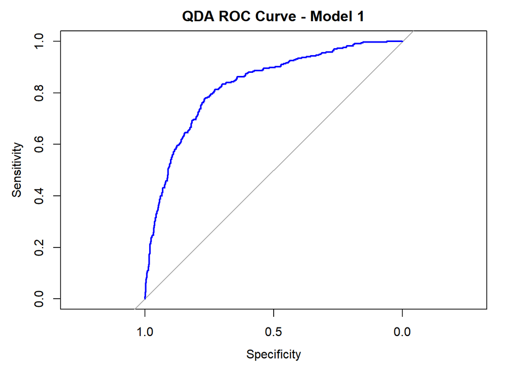

```r
plot(roc_obj_QDA1, main = "QDA ROC Curve - Model 1", col = "blue")
```

The **AUC** Of first attempt is **0.8294**.

#### 7.2.2 Second attempt, using all categorical independent variables from 7.2.1 without “Partner”

The plot below shows the ROC curve for the **attempt2**, helping us evaluate its **classification performance** in terms of sensitivity and specificity.

```r
# Establish QDA model
QDA_model_2 <- qda(Status ~ SeniorCitizen +  Dependents +
                             InternetService + PaperlessBilling + PaymentMethod +
                             Tenure + MonthlyCharges + ServiceCount,
                             data = training_set)

# Predict using test data
QDA_pred_2 <- predict(QDA_model_2, newdata = test_set)

# Extract probability of being classified as "Left"
churn_probs_QDA_2 <- QDA_pred_2$posterior[, "Left"]

# Generate ROC curve object
roc_obj_QDA_2 <- roc(test_set$Status, churn_probs_QDA_2,
                     levels = c("Current", "Left"), direction = "<")

# Calculate AUC and plot ROC curve
auc(roc_obj_QDA_2)
```

```
## Area under the curve: 0.8301
```

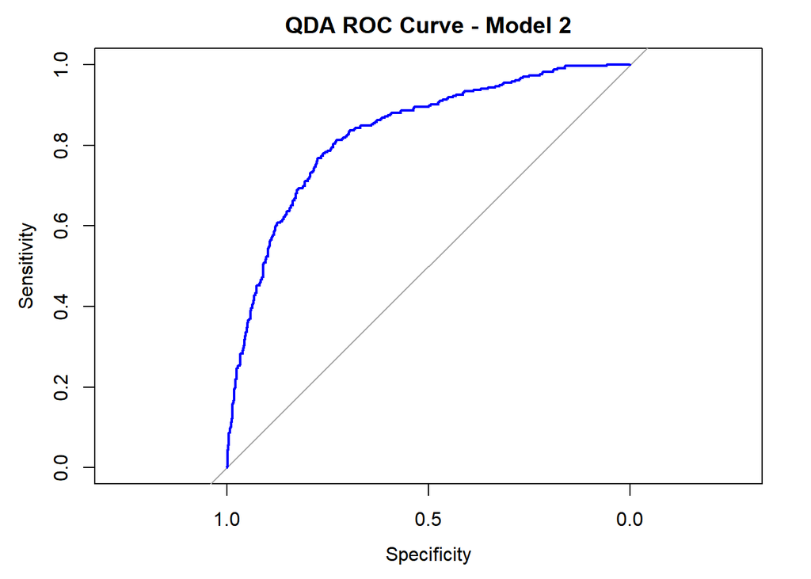

```r
plot(roc_obj_QDA_2, main = "QDA ROC Curve - Model 2", col = "blue")
```

The **AUC** Of second attempt is **0.8301**.

#### 7.2.3 Third attempt, using all categorical independent variables from 7.2.1 without “InternetService”

The plot below shows the ROC curve for the **attempt3**, helping us evaluate its **classification performance** in terms of sensitivity and specificity.

```r
# Establish QDA model
QDA_model_3 <- qda(Status ~ SeniorCitizen + Partner + Dependents +
                             PaperlessBilling + PaymentMethod +
                             Tenure + MonthlyCharges + ServiceCount,
                             data = training_set)

# Predict using test data
QDA_pred_3 <- predict(QDA_model_3, newdata = test_set)

# Extract probability of being classified as "Left"
churn_probs_QDA_3 <- QDA_pred_3$posterior[, "Left"]

# Generate ROC curve object
roc_obj_QDA_3 <- roc(test_set$Status, churn_probs_QDA_3,
                     levels = c("Current", "Left"), direction = "<")

# Calculate AUC and plot ROC curve
auc(roc_obj_QDA_3)
```

```
## Area under the curve: 0.833
```

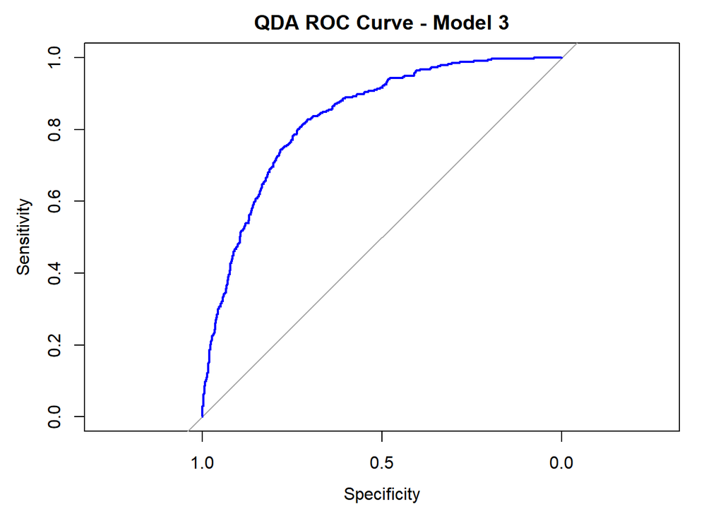

```r
plot(roc_obj_QDA_3, main = "QDA ROC Curve - Model 3", col = "blue")
```

After experimenting with several feature combinations, we found that removing the variable **InternetService**, which led to the highest **AUC (0.833).**

### 7.3 For the model with the highest AUC, try different thresholds to identify the threshold with the highest prediction accuracy on the test set

After identifying the QDA model with the highest AUC, we further optimized its classification performance by testing a range of probability thresholds.

```r
# Predicting probabilities on test set using the best QDA model
pred_prob_QDA_best <- predict(QDA_model_3, newdata = test_set)
churn_probs_best_QDA <- pred_prob_QDA_best$posterior[, "Left"]

# Create different threshold vectors
thresholds_QDA <- seq(0.1, 0.95, by = 0.05)

# Initialize result storage
accuracy_results_QDA <- data.frame(Threshold = thresholds_QDA, Accuracy_QDA = NA)

# Loop through each threshold and calculate accuracy
for (i in seq_along(thresholds_QDA)) {
  threshold <- thresholds_QDA[i]
  pred_class_QDA <- ifelse(churn_probs_best_QDA > threshold, 1, 0)
  accuracy_QDA <- mean(pred_class_QDA == test_set$Status_bin)
  accuracy_results_QDA$Accuracy_QDA[i] <- accuracy_QDA
}

# Find the best threshold
best_threshold_QDA <- accuracy_results_QDA[which.max(accuracy_results_QDA$Accuracy_QDA), ]
best_threshold_QDA
```

```
##    Threshold Accuracy_QDA
## 13       0.7    0.7961538
```

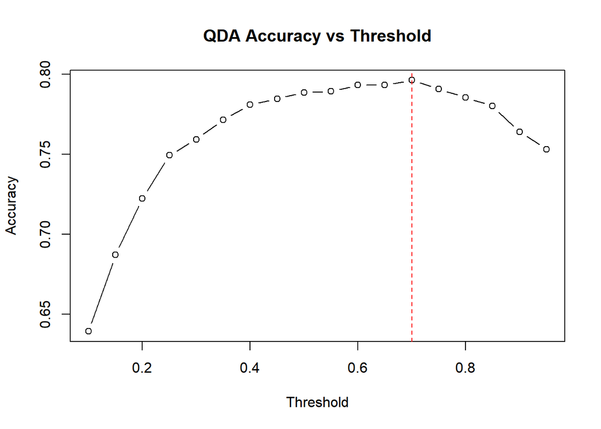

```r
# Plot accuracy vs threshold
plot(accuracy_results_QDA$Threshold, accuracy_results_QDA$Accuracy_QDA, type = "b",
     xlab = "Threshold", ylab = "Accuracy", main = "QDA Accuracy vs Threshold")
abline(v = best_threshold_QDA$Threshold, col = "red", lty = 2)
```

The threshold of the **highest prediction accuracy** on the test set is **0.7**.

## 8. Decision Trees

### 8.1 Use the training set to build a Decision Tree model to predict the probability for losing a customer.

#### 8.1.1 build a Decision Tree model with puring

We next applied a Decision Tree model to predict customer churn. To **improve model interpretability** and **avoid overfitting**, we applied **cost-complexity pruning** to determine the optimal tree size.

This technique identifies the simplest tree that still achieves strong predictive performance by balancing **model complexity** and **classification accuracy**.

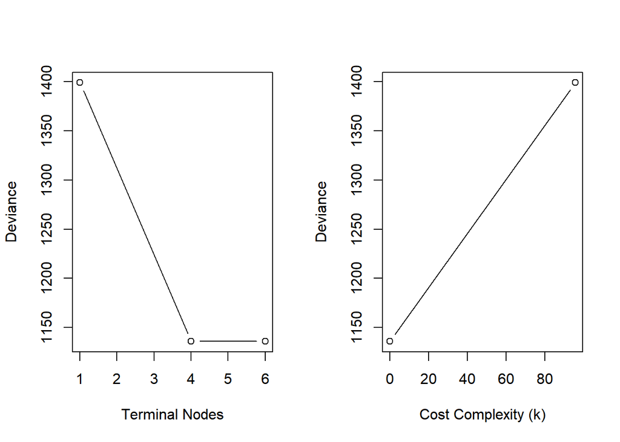

```r
#Establish an initial decision tree model
tree_model <- tree(Status ~ Gender + SeniorCitizen + Partner + Dependents +
                    PhoneService + MultipleLines + InternetService +
                    OnlineSecurity + DeviceProtection + StreamingMovies +
                    Contract + PaperlessBilling + PaymentMethod +
                    Tenure + MonthlyCharges,
                    data = training_set)
#Cross validation of tree models
cv_tree <- cv.tree(tree_model, FUN = prune.misclass)
#Visualize cross validation results
par(mfrow = c(1,2))
plot(cv_tree$size, cv_tree$dev, type = "b", xlab = "Terminal Nodes", ylab = "Deviance")
plot(cv_tree$k, cv_tree$dev, type = "b", xlab = "Cost Complexity (k)", ylab = "Deviance")
```

Based on the **complexity parameter (cp) plot**, the optimal tree size appears to be **4 terminal nodes**, as the deviance curve flattens beyond this point.

Pruning the tree to **4 nodes** offers a good trade-off between **model simplicity** and **predictive accuracy**, helping to avoid **overfitting** while still capturing the most important churn patterns.

After determining the optimal size, we **visualized the pruned decision tree** to interpret the **key decision rules** driving customer churn.

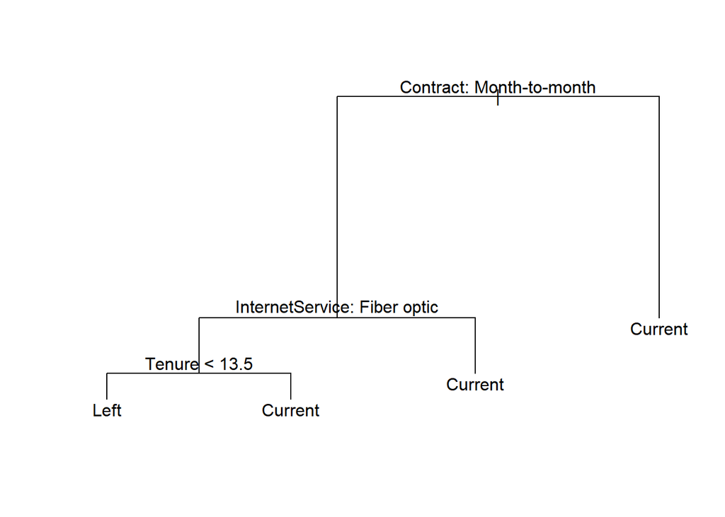

```r
# Pruning for optimal size（best = 4）
prune_model <- prune.misclass(tree_model, best = 4)

# Visualize the decision tree after pruning
plot(prune_model)
text(prune_model, pretty = 0)
```

- Interpreting the Pruned Decision Tree

The pruned decision tree reveals a **simple yet insightful structure** for predicting customer churn. The model identifies **three key decision rules** that define high-risk and low-risk customer segments:

1. **Contract Type**  
   The **first and most influential split** is based on the customer’s contract type.
   - Customers with **Month-to-month contracts** are **more likely to churn**.
   - Those with **One-year** or **Two-year contracts** are more likely to stay (**Current**).
2. **Internet Service Type**  
   Among customers on **Month-to-month contracts**, the next key factor is the **type of internet service**.
   - Customers with **Fiber optic** service undergo further evaluation.
   - Customers with other internet types are directly classified as **Current**.
3. **Tenure**  
   For **Fiber optic** users on **Month-to-month contracts**, the final rule is based on **Tenure**:
   - If **Tenure < 13.5 months**, the customer is classified as **Left** (higher churn risk).
   - If **Tenure ≥ 13.5 months**, the customer is predicted to stay.
- Insights from the Tree
- Customers with **Month-to-month contracts** and **short tenure** are the most likely to churn.
- Customers with **longer contracts** or **longer tenure**—even with Fiber optic—tend to be more stable.
- Other customer segments, particularly those with different internet types or contracts, are generally retained.

#### 8.1.2 Predict the probability for losing a customer

Next, we used the pruned Decision Tree model to predict the **likelihood of churn** for individual customers in the test set.

```r
# Predict class probabilities using the pruned decision tree
tree_pred_prob <- predict(prune_model, newdata = test_set, type = "vector")

# Extract probability of being classified as "Left"
churn_probs_tree <- tree_pred_prob[, "Left"]

# Preview first few churn probabilities
head(churn_probs_tree)
```

```
##         9        19        20        37        51        54
## 0.4391657 0.2742947 0.4391657 0.7001395 0.4391657 0.7001395
```

The pruned Decision Tree model was used to estimate the **probability** that **each customer in the test set would churn.**

Instead of assigning a binary prediction, the model outputs a **probability score** for each customer belonging to the “Left” class.

These probabilities reflect the model’s confidence that a customer will leave the company.

For example:

The second customer might have a **27.4%** chance of **churning**, suggesting **low churn risk.**

The fourth customer might have only a **70%** chance of **churning**, suggesting **high churn risk**.

In addition to individual predictions, we also calculated the average churn probability across all customers in the test set to assess the overall risk level.

```r
# Average predicted churn probability (i.e., average risk across test set)
mean_churn_prob_tree <- mean(churn_probs_tree)
mean_churn_prob_tree
```

```
## [1] 0.2676094
```

According to the Decison tree model’s prediction of test set customers, there is an **average probability of 26.8% for each customer to be lost**. This indicates that approximately **27% of the customers in the entire customer base are at risk of churn** as determined by the model.

### 8.2 Try different combinations of variables and identify the model with the largest prediction accuracy.

According to 8.1.1, contracts are the most effective factor in distinguishing loss rates. We combine contract variables with real business logic to test accuracy

#### 8.2.1 First attempt: Use all variables from 8.1.2

```r
# Predict class labels on the test set using the pruned tree
predicted_class <- predict(prune_model, newdata = test_set, type = "class")

# Generate confusion matrix
conf_mat <- table(Predicted = predicted_class, Actual = test_set$Status)

# Compute accuracy
accuracy <- mean(predicted_class == test_set$Status)
accuracy
```

```
## [1] 0.7992308
```

The **prediction accuracy** Of first attempt is **7992308**.

#### 8.2.2 Second attempt: Logic: Covering service preferences, cost structure, contract status, and payment habits.

```r
#Building the original decision tree
tree_model1 <- tree(Status ~  Contract + InternetService + OnlineSecurity +
         DeviceProtection + StreamingMovies +
         Tenure + MonthlyCharges + PaymentMethod, data = training_set)

#Cross validation and finding the optimal number of terminal nodes
cv_model <- cv.tree(tree_model1, FUN = prune.misclass)

#Automatically identify the optimal size
best_size <- cv_model$size[which.min(cv_model$dev)]

#Pruning
prune_model1 <- prune.misclass(tree_model1, best = best_size)

#Predicting using the pruned model
predicted_class1 <- predict(prune_model1, newdata = test_set, type = "class")

#Calculate accuracy
accuracy1 <- mean(predicted_class == test_set$Status)
accuracy1
```

```
## [1] 0.7992308
```

#### 8.2.2 Third attempt: Logic: Based on the combination of user demographic attributes, payment behavior, and contractual relationships

```r
#Building the original decision tree
tree_model2 <- tree(Status ~ SeniorCitizen + Partner + Dependents +
         Contract + PaperlessBilling + PaymentMethod +
         Tenure + MonthlyCharges, data = training_set)

#Cross validation and finding the optimal number of terminal nodes
cv_model2 <- cv.tree(tree_model2, FUN = prune.misclass)

#Automatically identify the optimal size
best_size2 <- cv_model$size[which.min(cv_model$dev)]

#Pruning
prune_model2 <- prune.misclass(tree_model2, best = best_size)

#Predicting using the pruned model
predicted_class2 <- predict(prune_model2, newdata = test_set, type = "class")

#Calculate accuracy
accuracy2 <- mean(predicted_class == test_set$Status)
accuracy2
```

```
## [1] 0.7992308
```

#### 8.2.2 Fourth attempt: More emphasis on digital contact behavior and service combination density, suitable for digital transformation operation strategies

```r
#Building the original decision tree
tree_model3 <- tree(Status ~ Contract + InternetService + OnlineSecurity +
         PaperlessBilling + Tenure + MonthlyCharges +
         IsTechComfortable + ServiceCount, data = training_set)

#Cross validation and finding the optimal number of terminal nodes
cv_model3 <- cv.tree(tree_model3, FUN = prune.misclass)

#Automatically identify the optimal size
best_size3 <- cv_model$size[which.min(cv_model$dev)]

#Pruning
prune_model3 <- prune.misclass(tree_model3, best = best_size)

#Predicting using the pruned model
predicted_class3 <- predict(prune_model3, newdata = test_set, type = "class")

#Calculate accuracy
accuracy3 <- mean(predicted_class == test_set$Status)
accuracy3
```

```
## [1] 0.7992308
```

Decision Tree Model – Accuracy Comparison

We evaluated several pruned decision tree models using different combinations of predictors to identify a model that achieves high accuracy with a more interpretable structure.

- **Original model (First attempt)**: Included 16 predictors related to customer demographics, service usage, and billing.
- **Second attempt** : Focused on 8 key predictors that combine service usage, contract type, billing method, and cost behavior.

## 9. Conclusion(Comparison Across Methods)

### 9.1 Compare across methods (skip the model built with decision trees) used above and report the best method based on ROC plots.

To compare the effectiveness of different classification methods, we plotted the ROC curves for **Logistic Regression, Naive Bayes, LDA, and QDA models** on the same test set.

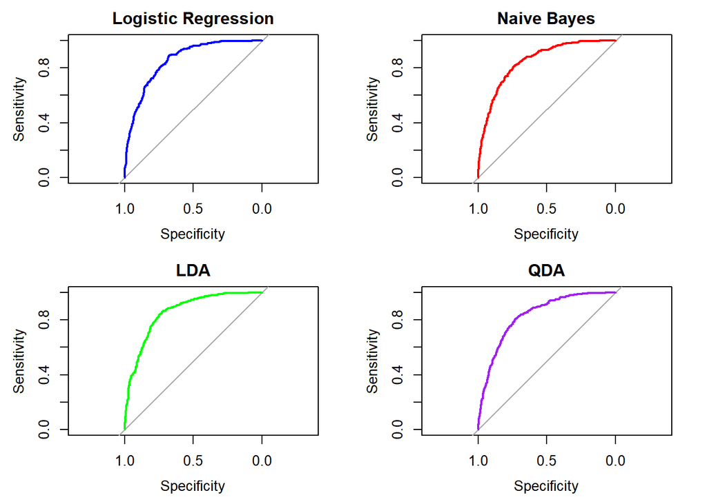

```r
par(mfrow = c(2, 2))  # Set the drawing area to 2 rows and 2 columns

# Draw four pictures in sequence
plot(roc_logit1, main = "Logistic Regression", col = "blue", lwd = 2)


plot(roc_obj_NB3, main = "Naive Bayes", col = "red", lwd = 2)


plot(roc_obj_3, main = "LDA", col = "green", lwd = 2)


plot(roc_obj_QDA_3, main = "QDA", col = "purple", lwd = 2)
```

To evaluate the predictive performance of different classification models, we compared the **Area Under the Curve (AUC)** values of the best versions of each method:

```r
# Build AUC comparison table
model_auc <- data.frame(
  Model = c("Logistic Regression", "Naive Bayes", "LDA", "QDA"),
  AUC = c(
    round(auc(roc_logit1), 4),
    round(auc(roc_obj_NB3), 4),
    round(auc(roc_obj_3), 4),
    round(auc(roc_obj_QDA_3), 4)
  )
)

# output table
kable(model_auc, caption = "AUC Comparison Across Classification Models")
```

AUC Comparison Across Classification Models

| Model | AUC |
| --- | --- |
| Logistic Regression | 0.8553 |
| Naive Bayes | 0.8493 |
| LDA | 0.8575 |
| QDA | 0.8330 |

Summary

- **LDA** achieved the highest AUC (0.8575), indicating the **best discrimination ability** between churned and retained customers among all models tested.
- **Logistic Regression** followed closely with an AUC of 0.8553, and **also offers strong interpretability**, making it an excellent candidate for business deployment.
- **Naive Bayes** performed surprisingly well (AUC = 0.8493) despite its strong independence assumptions, reinforcing its value as a baseline classifier.
- **QDA** had the lowest AUC (0.8330), potentially due to **overfitting** or limited variance structure in the training data.

Recommendation

While **LDA** has the best overall AUC, logistic regression remains preferable for deployment due to its **balance of performance, interpretability, and stability**. Other models (Naive Bayes, QDA) can serve as **supporting classifiers or benchmarks.**

### 9.2 Report the best model in terms of the prediction accuracy on the test set(Include the decision tree model here).

We evaluated each model’s prediction accuracy on the **test set** using its best-performing threshold (identified in previous sections). The table below summarizes the test set accuracy for all five models:

```r
model_acc <- data.frame(
  Model = c("Logistic Regression", "Naive Bayes", "LDA", "QDA", "Decision Tree"),
  Best_Threshold = c(0.5, 0.9, 0.6, 0.7, NA),  # DT uses class prediction directly
  Test_Accuracy = c(
    max(accuracy_results$Accuracy),
    max(accuracy_results_NB$Accuracy_NB),
    max(accuracy_results_LDA$Accuracy_LDA),
    max(accuracy_results_QDA$Accuracy_QDA),
    0.7992  # manually inserted from decision tree pruning result
  )
)

kable(model_acc, caption = "Test Set Accuracy Comparison Across Models")
```

Test Set Accuracy Comparison Across Models

| Model | Best_Threshold | Test_Accuracy |
| --- | --- | --- |
| Logistic Regression | 0.5 | 0.8053846 |
| Naive Bayes | 0.9 | 0.8076923 |
| LDA | 0.6 | 0.8084615 |
| QDA | 0.7 | 0.7961538 |
| Decision Tree | NA | 0.7992000 |

Summary

- **LDA** achieved the highest test set accuracy at **0.8085**, indicating the best classification performance on unseen data.
- **Naive Bayes** and **logistic regression** also performed well with accuracies of **0.8077** and **0.8054**, respectively.
- **Decision Tree** yielded a solid performance (**0.7992**) while offering superior interpretability and rule-based segmentation.
- **QDA** showed the lowest accuracy (**0.7962**) among the five models.

Recommendation

Based solely on test accuracy, **LDA** is the best-performing model. However, due to the logistic regression model’s comparable accuracy, clearer interpretation, and better model stability, it remains a strong candidate for deployment. Decision trees may also be used in conjunction for business explanation and customer targeting logic.

## 10. Business Analysis and Recommendations

With the modeling results in place, we now shift our focus to business interpretation. In this section, we examine key customer characteristics and churn patterns to provide actionable recommendations for improving customer retention.

### 10.1 Check data structure and missing values

```r
# load dataset "Implementation_Data"
load("Implementation_Data.rda")
```

Before applying the final model to the new dataset, we first examine the structure and quality of the data. This includes checking variable types, categorical levels, and identifying any missing or inconsistent values. Ensuring the data is clean and consistent is critical for generating reliable churn predictions.

```r
# check the structrue of the dataset
str(Implementation_Data)
```

```
## 'data.frame':    500 obs. of  16 variables:
##  $ Gender          : Factor w/ 2 levels "Female","Male": 2 1 1 2 2 2 2 1 1 2 ...
##  $ SeniorCitizen   : int  0 0 1 1 1 0 0 1 0 0 ...
##  $ Partner         : Factor w/ 2 levels "No","Yes": 2 2 2 2 1 1 2 1 2 1 ...
##  $ Dependents      : Factor w/ 2 levels "No","Yes": 2 2 1 1 1 1 2 1 1 1 ...
##  $ Tenure          : int  45 64 26 23 26 2 67 71 2 72 ...
##  $ PhoneService    : Factor w/ 2 levels "No","Yes": 2 2 2 2 2 2 2 2 2 2 ...
##  $ MultipleLines   : Factor w/ 3 levels "No","No phone service",..: 1 3 1 1 1 3 1 3 1 1 ...
##  $ InternetService : Factor w/ 3 levels "DSL","Fiber optic",..: 3 2 1 3 3 3 1 2 1 3 ...
##  $ OnlineSecurity  : Factor w/ 3 levels "No","No internet service",..: 2 3 1 2 2 2 3 3 1 2 ...
##  $ DeviceProtection: Factor w/ 3 levels "No","No internet service",..: 2 1 3 2 2 2 1 1 1 2 ...
##  $ StreamingMovies : Factor w/ 3 levels "No","No internet service",..: 2 3 3 2 2 2 1 1 1 2 ...
##  $ Contract        : Factor w/ 3 levels "Month-to-month",..: 3 3 2 2 2 1 3 2 1 3 ...
##  $ PaperlessBilling: Factor w/ 2 levels "No","Yes": 1 1 1 2 1 1 2 2 2 2 ...
##  $ PaymentMethod   : Factor w/ 4 levels "Bank transfer (automatic)",..: 3 1 4 3 2 4 1 2 2 2 ...
##  $ MonthlyCharges  : num  19.2 110.3 60.7 20.8 19.3 ...
##  $ TotalCharges    : num  904 6997 1597 485 504 ...
```

We converted `SeniorCitizen` from integer to factor because it represents a categorical variable (0 = No, 1 = Yes). Treating it as a factor ensures it is interpreted correctly in visualizations and modeling, rather than as a continuous numeric variable.

```r
# tramsform "SeniorCitizen" into factor
Implementation_Data$SeniorCitizen <- as.factor(Implementation_Data$SeniorCitizen)
```

Check the distribution of data to see if there are any missing data

```r
# check the distribution of each variable
summary(Implementation_Data)
```

```
##     Gender    SeniorCitizen Partner   Dependents     Tenure      PhoneService
##  Female:235   0:414         No :248   No :343    Min.   : 1.00   No : 48
##  Male  :265   1: 86         Yes:252   Yes:157    1st Qu.:11.00   Yes:452
##                                                  Median :31.00
##                                                  Mean   :33.94
##                                                  3rd Qu.:56.00
##                                                  Max.   :72.00
##           MultipleLines    InternetService             OnlineSecurity
##  No              :231   DSL        :184    No                 :254
##  No phone service: 48   Fiber optic:220    No internet service: 96
##  Yes             :221   No         : 96    Yes                :150
##
##
##
##             DeviceProtection            StreamingMovies           Contract
##  No                 :225     No                 :207    Month-to-month:266
##  No internet service: 96     No internet service: 96    One year      :113
##  Yes                :179     Yes                :197    Two year      :121
##
##
##
##  PaperlessBilling                   PaymentMethod MonthlyCharges
##  No :204          Bank transfer (automatic):109   Min.   : 18.75
##  Yes:296          Credit card (automatic)  :118   1st Qu.: 44.60
##                   Electronic check         :179   Median : 70.33
##                   Mailed check             : 94   Mean   : 65.95
##                                                   3rd Qu.: 89.86
##                                                   Max.   :115.80
##   TotalCharges
##  Min.   :  19.75
##  1st Qu.: 484.91
##  Median :1501.12
##  Mean   :2407.88
##  3rd Qu.:3970.12
##  Max.   :8476.50
```

There is no missing data in the “Implementation_Data” and all data variable types are appropriate

### 10.2 Data variable preparation

We created the variable `IsLongTermCustomer` using the condition `Tenure >= 12`, consistent with the logistic regression model used earlier. This variable identifies customers who have stayed with the company for at least one year and helps differentiate between long-term and short-term customers.

```r
Implementation_Data_cleaned <- Implementation_Data %>%
mutate(
# Create Long term customer variables according to the original model logic
IsLongTermCustomer = ifelse(Tenure >= 12, "Yes", "No"),
#Force conversion to factor type
IsLongTermCustomer = as.factor(IsLongTermCustomer)
)
```

Recheck the data structure

```r
# check the structrue of the dataset again
str(Implementation_Data_cleaned)
```

```
## 'data.frame':    500 obs. of  17 variables:
##  $ Gender            : Factor w/ 2 levels "Female","Male": 2 1 1 2 2 2 2 1 1 2 ...
##  $ SeniorCitizen     : Factor w/ 2 levels "0","1": 1 1 2 2 2 1 1 2 1 1 ...
##  $ Partner           : Factor w/ 2 levels "No","Yes": 2 2 2 2 1 1 2 1 2 1 ...
##  $ Dependents        : Factor w/ 2 levels "No","Yes": 2 2 1 1 1 1 2 1 1 1 ...
##  $ Tenure            : int  45 64 26 23 26 2 67 71 2 72 ...
##  $ PhoneService      : Factor w/ 2 levels "No","Yes": 2 2 2 2 2 2 2 2 2 2 ...
##  $ MultipleLines     : Factor w/ 3 levels "No","No phone service",..: 1 3 1 1 1 3 1 3 1 1 ...
##  $ InternetService   : Factor w/ 3 levels "DSL","Fiber optic",..: 3 2 1 3 3 3 1 2 1 3 ...
##  $ OnlineSecurity    : Factor w/ 3 levels "No","No internet service",..: 2 3 1 2 2 2 3 3 1 2 ...
##  $ DeviceProtection  : Factor w/ 3 levels "No","No internet service",..: 2 1 3 2 2 2 1 1 1 2 ...
##  $ StreamingMovies   : Factor w/ 3 levels "No","No internet service",..: 2 3 3 2 2 2 1 1 1 2 ...
##  $ Contract          : Factor w/ 3 levels "Month-to-month",..: 3 3 2 2 2 1 3 2 1 3 ...
##  $ PaperlessBilling  : Factor w/ 2 levels "No","Yes": 1 1 1 2 1 1 2 2 2 2 ...
##  $ PaymentMethod     : Factor w/ 4 levels "Bank transfer (automatic)",..: 3 1 4 3 2 4 1 2 2 2 ...
##  $ MonthlyCharges    : num  19.2 110.3 60.7 20.8 19.3 ...
##  $ TotalCharges      : num  904 6997 1597 485 504 ...
##  $ IsLongTermCustomer: Factor w/ 2 levels "No","Yes": 2 2 2 2 2 1 2 2 1 2 ...
```

All data structures are well structured

### 10.3 In terms of relative importance,rate the predictors in model.

#### 10.3.1 Choose Random Forest was chosen for variable importance analysis

Random Forest Variable Importance

In this customer churn analysis, we selected the **Random Forest** algorithm to assess the **relative importance** of predictor variables.  
Given the business goal is to **understand which features most influence churn risk**, Random Forest is particularly suitable for the following reasons:

- **Robust to variable types and interactions**: Random Forest handles both categorical and numeric predictors without requiring linear assumptions or variable transformation. This fits well with our mixed-type variables such as `Tenure`, `Contract`, and `InternetService`.
- **Captures nonlinear effects and interactions**: Customer churn behavior is often influenced by complex interactions (e.g., tenure interacting with contract type). Random Forest automatically captures these effects, making it valuable for understanding real-world drivers of churn.
- **Reliable importance ranking with limited predictors**: Since our model includes only six carefully selected variables, Random Forest can generate **clear, interpretable importance scores** without dilution from high-dimensional noise—ensuring decision-makers focus on what truly matters.
- **Business interpretability**: The ranked importance outputs (e.g., `MeanDecreaseAccuracy`) allow business teams to prioritize actions (e.g., re-engagement for short-tenure customers or adjustments in internet service offerings).

Importantly, because our dataset includes labeled outcomes (i.e., whether a customer **churned or stayed**), this analysis effectively reflects **which features historically drove churn**.

In other words, **Random Forest helps us mine insights from past customer behavior** to inform future retention strategies.

**Conclusion**: Random Forest provides a balanced, data-driven method for surfacing the most influential predictors in our churn model, offering both **interpretability and business relevance**.

```r
# Ensure the response variable is a factor
rf_response <- as.factor(Model_Building_Data_cleaned$Status)

# Select the same predictors used in the logistic regression model
rf_predictors <- Model_Building_Data_cleaned %>%
  dplyr::select(Tenure, InternetService, Contract, PaperlessBilling,
         PaymentMethod, IsLongTermCustomer)

# Fit the Random Forest model
set.seed(1401)
rf_model <- randomForest(x = rf_predictors, y = rf_response, importance = TRUE)

# Extract and sort variable importance by MeanDecreaseAccuracy
importance_vals <- importance(rf_model)
importance_sorted <- importance_vals[order(importance_vals[, "MeanDecreaseAccuracy"], decreasing = TRUE), ]

# check the outcome
importance_sorted
```

```
##                       Current     Left MeanDecreaseAccuracy MeanDecreaseGini
## InternetService     20.187432 44.53185             60.60640        176.92371
## Tenure              11.372661 32.02425             36.19888        215.48718
## Contract           -25.892328 43.98410             32.38900        247.05080
## PaymentMethod      -12.207483 24.86673             23.70349        104.16259
## PaperlessBilling    -6.481656 19.70906             18.17911         30.23303
## IsLongTermCustomer   6.095864 13.35690             15.78243         69.51529
```

The plots below rank the predictors based on their contribution to model accuracy and node purity

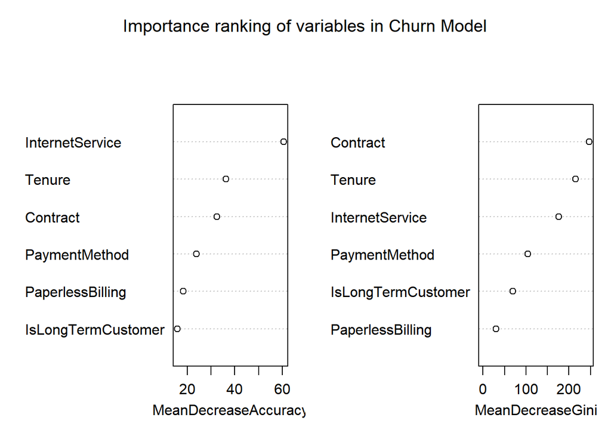

```r
varImpPlot(rf_model,main = "Importance ranking of variables in Churn Model")
```

#### 10.3.2 Perform PCA to identify the main directions explaining the variation

Since the current dataset **does not include churn status**, it can be interpreted as a snapshot of **active users in the current quarter**.  
Therefore, instead of applying supervised learning, we use an unsupervised approach—**Principal Component Analysis (PCA)**—to identify the main underlying patterns in customer attributes.

PCA helps reduce dimensionality and **highlights key directions of variation in the data**, which is particularly valuable when variables are potentially correlated and when we aim to better understand distinct customer profiles.

This approach allows us to extract **important behavioral or usage-based factors** even without churn labels, offering actionable insights into the current customer base for **segmentation, targeting, or retention planning**.

The following table shows the variable **loadings** for the first principal component, indicating each variable’s contribution to the **most significant direction of variation.**

```r
# Select all current customers+6 variables
pca_data <- Implementation_Data_cleaned %>%
  dplyr::select(Tenure, InternetService, Contract, PaperlessBilling,
  PaymentMethod, IsLongTermCustomer)

# Create a numerical dummy matrix
pca_matrix <- model.matrix(~ . - 1, data = pca_data)

# Perform PCA
pca_result <- prcomp(pca_matrix, scale. = TRUE)

# Extract PC1 loading and sort it
PC1_loadings <- pca_result$rotation[, 1]
PC1_df <- data.frame(Loading = PC1_loadings) %>%
arrange(desc(abs(Loading)))

# View the variable with the highest contribution
PC1_df
```

```
##                                          Loading
## PaymentMethodElectronic check         0.44915174
## InternetServiceFiber optic            0.42945149
## ContractTwo year                     -0.36500395
## Tenure                               -0.31895232
## PaperlessBillingYes                   0.30601506
## IsLongTermCustomerYes                -0.28897172
## InternetServiceDSL                   -0.25378016
## InternetServiceNo                    -0.23049494
## PaymentMethodMailed check            -0.20203742
## PaymentMethodCredit card (automatic) -0.19191107
## ContractOne year                     -0.08089827
```

Principal Component Analysis on Current Customers

we conducted a principal component analysis (PCA) using the same six variables across all current customers. The **first principal component (PC1)** captures the dominant axis of variation in the data and aligns closely with churn-related behavioral patterns.

- Variables with the largest absolute loadings on PC1—**PaymentMethod (Electronic check)**, **InternetService (Fiber optic)**, and **Contract (Two year)**—reflect a **clear contrast** between high-risk and stable customers. Specifically, **customers using electronic checks and fiber optic internet** tend to load positively on PC1 (indicating higher churn risk), whereas those with **long-term contracts and higher tenure** load negatively.
- These findings reinforce the validity of our feature selection and modeling strategy, as both the random forest importance scores and PCA results highlight **contract commitment**, **payment behavior**, and **service type** as central to customer retention dynamics.
- This multi-method agreement strengthens our confidence in using these variables to guide segmentation and tailor incentive strategies in the following sections.

### 10.4 Predicting the churn probability and results of Implemented_Data using a trained logistic regression model

To facilitate churn risk tracking across the entire customer base, the table below presents the **predicted churn probabilities** for all customers in the `Implemented_Data`. Instead of highlighting only high-risk cases, this interactive table allows users to **search, sort, and monitor churn probability** at the individual level, supporting continuous risk management and customer retention planning.

```r
# Predict the probability of loss
Implementation_Data_cleaned$predicted_prob <- predict(logit_model2, newdata = Implementation_Data_cleaned, type = "response")

# Determine whether there is a loss based on a threshold of 0.5
Implementation_Data_cleaned$predicted_churn <- ifelse(Implementation_Data_cleaned$predicted_prob >= 0.5, "Yes", "No")

churn_summary <- Implementation_Data_cleaned %>%
  mutate(CustomerID = row_number()) %>%
  dplyr::select(CustomerID, predicted_prob, predicted_churn)

churn_summary <- churn_summary %>%
  mutate(predicted_prob = round(predicted_prob, 4))

datatable(churn_summary, caption = "Interactive Churn Prediction Table",rownames = FALSE)
```

| CustomerID | predicted_prob | predicted_churn |
| --- | --- | --- |
| 1 | 0.0154 | No |
| 2 | 0.0498 | No |
| 3 | 0.0758 | No |
| 4 | 0.0786 | No |
| 5 | 0.0313 | No |
| 6 | 0.1713 | No |
| 7 | 0.0238 | No |
| 8 | 0.1267 | No |
| 9 | 0.4046 | No |
| 10 | 0.0082 | No |

[output cut: 490 more lines]

Predicted Churn number

```r
# Statistically predict the number of lost personnel
num_predicted_churn <- sum(Implementation_Data_cleaned$predicted_churn == "Yes")
num_predicted_churn
```

```
## [1] 101
```

Based on our logistic regression model with a 0.5 threshold, the model **predicts that 101 out of 500 customers (20.2%) are at risk of churning** in the implementation dataset.

This insight allows the business to focus retention efforts on the top 20% most vulnerable customers.

### 10.5 If no action is taken, predict the loss in revenue per month if all these customers leave .

Predicted Monthly Revenue Loss

```r
#Calculate the monthly income loss of these customers
monthly_loss <- sum(Implementation_Data_cleaned$MonthlyCharges[Implementation_Data_cleaned$predicted_churn == "Yes"])
monthly_loss
```

```
## [1] 8310.85
```

If no retention action is taken, and all **101 customers** predicted to churn actually leave, the **estimated monthly revenue loss** would be approximately **$8,310.85**.

Since the model predicts that these 101 customers will be lost, we attempt to discover their commonalities in core variables (Tenure, Internet Service, Payment Method, etc.) through unsupervised study, in order to customize more targeted retention strategies.

To better understand the characteristics of customers predicted to churn, we applied **hierarchical clustering**.  
This method is well-suited for our analysis because the sample size is **relatively small (n = 101)** and the dataset contains a mix of **categorical and numerical variables**.  
Unlike other methods, hierarchical clustering does **not require pre-specifying the number of clusters**, which helps explore the data structure more freely.  
The resulting **dendrogram** provides a clear visualization of how customers naturally group together, allowing us to identify **distinct segments** based on key predictors.  
This complements our previous **supervised learning** by offering a **customer-centered perspective** on who is at risk and why, enhancing targeted retention strategies.

To further explore the **similarities among high-risk customers**, we performed hierarchical clustering on those with high predicted churn probabilities. The dendrograms below illustrate the customer grouping results using three linkage methods: **Complete, Average, and Single linkage.** These visualizations help us identify **sub-segments** within the high-risk group, which can be targeted with tailored retention strategies.

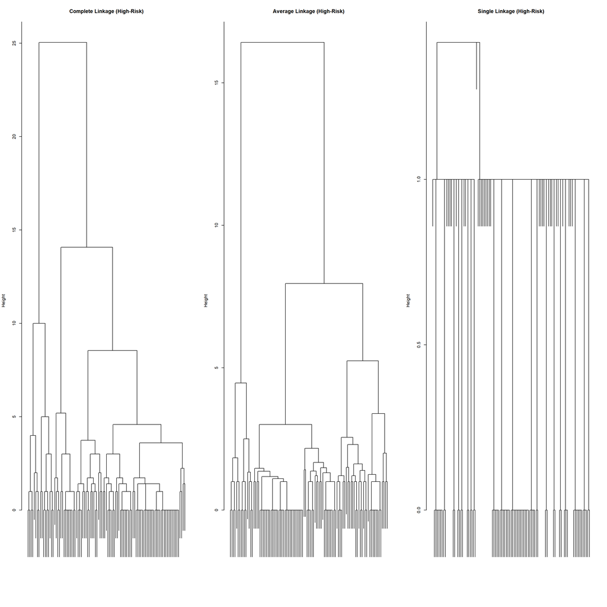

```r
# Step 1: Filter only customers predicted as 'Yes' to churn
high_risk_data <- Implementation_Data_cleaned %>%
  filter(predicted_churn == "Yes") %>%
  dplyr::select(Tenure, InternetService, Contract, PaperlessBilling,
                PaymentMethod, IsLongTermCustomer)

# Step 2: Convert categorical variables to numeric for clustering
high_risk_numeric <- high_risk_data %>%
  mutate(across(everything(), as.factor)) %>%
  mutate(across(everything(), as.numeric))

# Step 3: Compute distance matrix
dist_matrix_hr <- dist(high_risk_numeric)

# Step 4: Try three linkage methods for hierarchical clustering
hc.complete.hr <- hclust(dist_matrix_hr, method = "complete")
hc.average.hr  <- hclust(dist_matrix_hr, method = "average")
hc.single.hr   <- hclust(dist_matrix_hr, method = "single")

# Step 5: Plot all three dendrograms for comparison
par(mfrow = c(1, 3))

plot(hc.complete.hr, main = "Complete Linkage (High-Risk)", xlab = "", sub = "", cex = 0.6, labels = FALSE)
plot(hc.average.hr,  main = "Average Linkage (High-Risk)",  xlab = "", sub = "", cex = 0.6, labels = FALSE )
plot(hc.single.hr,   main = "Single Linkage (High-Risk)",   xlab = "", sub = "", cex = 0.6, labels = FALSE)
```

We selected **Complete Linkage** as the hierarchical clustering method for analyzing high-risk customers for the following reasons:

- **Clear cluster structure**: The dendrogram produced by complete linkage shows a well-defined hierarchy, making it easier to identify distinct customer segments.
- **Compact within-cluster similarity and strong between-cluster separation**: This method tends to form groups that are **internally cohesive and externally distinct**, which supports clearer interpretation of high-risk customer patterns.
- **Avoidance of chaining effect**: Compared to single linkage, complete linkage minimizes the “chaining” issue that can result in elongated and misleading clusters.
- **Strong interpretability**: The distinct height differences between branches help us determine the appropriate number of clusters and interpret each segment’s behavior more reliably.

Based on these advantages, we believe **Complete Linkage is the most suitable hierarchical clustering method** for this project, enabling us to better understand the profiles of customers at high risk of churn.

```r
# Use complete linkage
high_risk_clusters <- cutree(hc.complete.hr, k = 3)

# Add the clustering results back to the original data (high-risk customers)
clustered_data <- high_risk_data %>%
mutate(Cluster = as.factor(high_risk_clusters))
```

To better understand the **behavioral patterns** within each customer segment, we computed a set of summary statistics by cluster. The table below presents **key characteristics** such as average tenure and the proportion of customers with fiber-optic internet, locked contracts, paperless billing, electronic check payments, and long-term relationships.

```r
# Summarize key logistic regression predictors by cluster
cluster_summary <- clustered_data %>%
  group_by(Cluster) %>%
  summarise(
    Customer_Count = n(),
    Avg_Tenure = mean(Tenure),
    Proportion_FiberInternet = mean(InternetService == "Fiber optic"),
    Proportion_ContractLocked = mean(Contract != "Month-to-month"),
    Proportion_Paperless = mean(PaperlessBilling == "Yes"),
    Proportion_ElectronicCheck = mean(PaymentMethod == "Electronic check"),
    Proportion_LongTerm = mean(IsLongTermCustomer == "Yes")
  )

knitr::kable(cluster_summary, digits = 2)
```

| Cluster | Customer_Count | Avg_Tenure | Proportion_FiberInternet | Proportion_ContractLocked | Proportion_Paperless | Proportion_ElectronicCheck | Proportion_LongTerm |
| --- | --- | --- | --- | --- | --- | --- | --- |
| 1 | 70 | 3.63 | 0.86 | 0 | 0.83 | 0.73 | 0.00 |
| 2 | 17 | 27.94 | 1.00 | 0 | 1.00 | 1.00 | 1.00 |
| 3 | 14 | 13.64 | 1.00 | 0 | 0.93 | 1.00 | 0.79 |

Cluster Profile Summary

To better understand the different segments within the **high-risk** customer group, we performed hierarchical clustering based on key predictors from the logistic regression model. The results show clear differences across the three identified clusters:

Overall, we observe that **lack of contract** is a common trait across all high-risk clusters. Additionally, **electronic check payment** and **fiber internet** usage are prevalent among these at-risk customers. This suggests the company should consider offering **contract incentives or discounts for digital payment customers** to improve retention in these segments.

### 10.6 Key Factors to Focus on for Reducing Customer Churn Through Incentives or Promotions

To further understand the high-risk customer profiles, we conducted a **hierarchical clustering analysis** on customers predicted to churn. The results revealed three distinct sub-groups, each with unique characteristics:

- **Cluster 1**: Short-tenure customers (avg. tenure ≈ 3.6 months), no long-term commitment, and mostly pay via **electronic check**. These customers are **early-stage users** with **no contract lock-in**, making them **highly vulnerable to churn**.  
  → **Recommendation**: Offer **new customer incentives**, such as introductory discounts or loyalty milestones, to increase tenure and perceived value.
- **Cluster 2**: Long-tenure users (avg. tenure ≈ 28 months), all using **fiber internet**, **paperless billing**, and **electronic checks**, but none under contract. Despite long history, their **lack of contract** suggests a risk of switching if competitors offer better deals.  
  → **Recommendation**: Promote **contract-based loyalty plans** or provide **special discounts** for long-tenure users to reinforce retention.
- **Cluster 3**: Medium-tenure users with moderate engagement, also paying via **electronic check** and favoring **fiber internet**.  
  → **Recommendation**: Encourage **alternative payment methods** (e.g., auto-pay credit card) with cashback or fee waivers, as payment method was identified as an influential churn predictor.

In summary, we recommend focusing on the following key areas to reduce churn: - **Retaining short-tenure customers** with onboarding incentives and early loyalty bonuses. - **Contract-based promotions** for long-tenure but unlocked customers. - **Targeted messaging** encouraging payment method changes to reduce churn risk.

These strategies are directly informed by both the machine learning model’s feature importance and the unsupervised clustering insights from our implementation data.

### 10.7 Propose an incentive scheme that can help reduce the loss in revenue by retaining some (or all) customers.

Based on our **random forest results** and **cluster analysis** of high-risk customers, we identified three distinct at-risk segments, each with unique behavioral patterns. Below, we outline not only the key churn-driving factors but also **precisely tailored incentive strategies** to mitigate churn risk:

- **Cluster 1: Early-stage customers (avg. tenure ≈ 3.6 months)**  
  **Key Risk Factors:** No long-term contract, reliance on **paperless billing**, and use of **electronic check** as payment method.  
  **Revised Incentive Strategy:**  
  Offer an **onboarding retention package** that includes a **$10/month bill credit** over a **12-month contract**. This modest, recurring incentive encourages early engagement while creating a longer-term commitment with minimal financial exposure.
- **Cluster 2: Long-tenure, contract-unlocked users (avg. tenure ≈ 28 months)**  
  **Key Risk Factors:** Use of **fiber optic internet** with **no active contract**, despite long company history.  
  **Revised Incentive Strategy:**  
  Introduce a **loyalty-based retention offer** in the form of a **$15/month discount** for customers who commit to a **12-month contract**. This structure rewards loyalty while significantly reducing churn risk at a controlled cost.
- **Cluster 3: Mid-tenure, moderate engagement customers**  
  **Key Risk Factors:** No bundled services, reliance on **electronic check** rather than auto-pay, limited use of premium services.  
  **Revised Incentive Strategy:**  
  Provide a **$20/month bundling bonus** for customers who enroll in **full-service packages** or switch to **auto-pay via credit card** and meanwhile commit to a **12-month contract**. This drives both service depth and billing reliability, fostering longer-term retention.

### 10.8 Business Case for Retaining High-Risk Customers: Cost-Benefit Analysis of the Proposed Incentive Scheme

Below is the average of all customer groups will be used as the monthly expense

```r
mean(Implementation_Data_cleaned$MonthlyCharges, na.rm = TRUE)
```

```
## [1] 65.9484
```

The **average monthly charge** for customers is approximately **$65.95.** This value will be used as the base revenue estimate in the incentive cost-benefit analysis.

Based on the clustering results, we designed **differentiated incentive plans for each segment**. The table below summarizes the number of customers per cluster, average monthly charges, contract duration, assigned monthly incentive, total expected revenue, total incentive cost, and the resulting net benefit from implementing the retention program.

```r
# create dataframe for caculation
cluster_data <- data.frame(
  Cluster = c("Cluster 1", "Cluster 2", "Cluster 3"),
  Customer_Count = c(70, 17, 14),
  Avg_MonthlyCharges = rep(65.9484, 3),
  Contract_Months = rep(12, 3),
  Monthly_Incentive = c(10, 15, 20)
)

# Calculate benefits and costs
cluster_data$Revenue <- cluster_data$Customer_Count * cluster_data$Avg_MonthlyCharges * cluster_data$Contract_Months
cluster_data$Incentive_Cost <- cluster_data$Customer_Count * cluster_data$Monthly_Incentive * cluster_data$Contract_Months
cluster_data$Net_Benefit <- cluster_data$Revenue - cluster_data$Incentive_Cost

# show the outcome among 3 cluster customers
cluster_data
```

```
##     Cluster Customer_Count Avg_MonthlyCharges Contract_Months Monthly_Incentive
## 1 Cluster 1             70            65.9484              12                10
## 2 Cluster 2             17            65.9484              12                15
## 3 Cluster 3             14            65.9484              12                20
##    Revenue Incentive_Cost Net_Benefit
## 1 55396.66           8400   46996.656
## 2 13453.47           3060   10393.474
## 3 11079.33           3360    7719.331
```

```r
# Summary revenue, cost and net benefit
total_revenue <- sum(cluster_data$Revenue)
total_cost <- sum(cluster_data$Incentive_Cost)
total_net_benefit <- total_revenue - total_cost
```

Below is the total estimated revenue generated from customers who accepted the incentive and renewed for another contract term.

```r
total_revenue
```

```
## [1] 79929.46
```

Below is the total cost incurred from offering retention incentives to all targeted high-risk customers.

```r
total_cost
```

```
## [1] 14820
```

Below is the net benefit is calculated as total revenue minus total incentive cost, demonstrating the financial gain from this targeted customer retention initiative.

```r
total_net_benefit
```

```
## [1] 65109.46
```

10.8.1 Overall Business Case Summary

Implementing the revised monthly incentive program across our three identified high-risk customer clusters is projected to generate substantial value. By offering **targeted monthly discounts** of **$10**, **$15**, and **$20** respectively, we estimate the following:

- Total projected **contract-based revenue*:* $79929.46**
- Total projected **incentive cost*:* $14820**
- **Total net benefit**: **$65,109.46**

This outcome demonstrates a strong **return on investment**, especially considering that the incentives are small relative to the monthly charges. We recommend implementing this incentive plan as a **scalable, low-cost retention strategy** that aligns well with customer behavior and risk profiles.

## Appendix

### Full variable dictionary

1. **Status**: If it is a Current customer or someone who has Left.
2. **SeniorCitizen**: Whether the customer is a senior citizen or not (1, 0)
3. **Partner**: Has a partner (Yes, No)
4. **Dependents**: Has dependents (Yes, No)
5. **Tenure**: Number of months with the company
6. **PhoneService**: Has a phone service (Yes, No)
7. **MultipleLines**: Has multiple lines (Yes, No, No phone service)
8. **InternetService**: Customer’s Internet Service Provider (DSL, Fiber optic, No)
9. **OnlineSecurity**: Customer has online security or not (Yes, No, No internet service)
10. **DeviceProtection**: Customer has device protection or not (Yes, No, No internet service)
11. **Contract**: The contract term of the customer (Month-to-month, One year, Two year)
12. **PaperlessBilling**: Customer has paperless billing or not (Yes, No)
13. **PaymentMethod**: The customer’s payment method (Electronic check, Mailed check, Bank transfer (automatic), Credit card (automatic))
14. **MonthlyCharges**: The amount charged to the customer monthly
15. **TotalCharges**: The total amount charged to the customer
16. **Gender**: Male, Female

### Explanation of Machine Learning Terms

To support readers without a technical background, this appendix provides concise explanations of key machine learning techniques and terminology used throughout the report.

#### 1. Logistic Regression

A statistical model that estimates the **probability of a binary outcome** (e.g., customer churn or not) based on input variables. It is commonly used in business analytics due to its simplicity and interpretability.

- **Output**: Probability between 0 and 1
- **Interpretation**: Coefficients show how each variable influences churn odds

#### 2. Lasso Logistic Regression

A version of logistic regression that adds a **penalty term** to reduce complexity and automatically eliminate less important variables (i.e., feature selection).

- **Benefit**: Helps avoid overfitting and focuses on the most impactful predictors

#### 3. Naive Bayes Classifier

A simple probabilistic model that applies **Bayes’ theorem** under the assumption that features are conditionally independent.

- **Strengths**: Fast, scalable, and often effective even when assumptions are violated
- **Limitation**: Assumes variables are independent, which may not always hold

#### 4. Linear Discriminant Analysis (LDA)

A classification method that finds a **linear boundary** to separate two or more classes based on maximizing the separation between group means while minimizing variance within each group.

- **Assumption**: Predictors are normally distributed with **equal covariance matrices** across classes

#### 5. Quadratic Discriminant Analysis (QDA)

An extension of LDA that allows each class to have its **own covariance matrix**, enabling **nonlinear separation** between groups.

- **Benefit**: More flexible than LDA
- **Risk**: May overfit on small or imbalanced datasets

#### 6. Decision Tree

A rule-based model that splits data into segments based on feature values, forming a tree structure.

- **Advantage**: Easy to visualize and interpret
- **Pruning**: Reduces tree size to prevent overfitting and improve generalization

#### 7. Random Forest

An ensemble learning method that builds **many decision trees** and combines their results.

- **Key Use in This Report**: Identifying the most important variables for predicting churn
- **Metric Used**: *MeanDecreaseAccuracy* – shows how removing a variable affects model accuracy

#### 8. AUC (Area Under the ROC Curve)

A performance metric for classification models that measures how well a model distinguishes between classes.

- **Value Range**: 0.5 (no skill) to 1.0 (perfect classification)
- **Interpretation**: Higher AUC indicates better model performance

#### 9. Confusion Matrix

A table showing the number of correct and incorrect predictions, broken down by actual vs. predicted outcomes.

- **Key Terms**:
  - **Accuracy**: Overall correctness
  - **Sensitivity (Recall)**: Ability to correctly identify churners
  - **Specificity**: Ability to correctly identify non-churners

#### 10. Principal Component Analysis (PCA)

An **unsupervised** technique that reduces dimensionality by finding new variables (components) that explain the most variance in the data.

- **Use in Report**: To explore customer patterns without using churn labels

#### 11. Clustering (Hierarchical)

A method that groups similar data points into clusters based on their features.

- **Dendrogram**: A tree-like diagram that shows how clusters are formed at various distances
- **Use in Report**: To identify distinct sub-groups within high-risk churn customers

#### 12. Threshold Selection

The probability cutoff at which a customer is classified as “churn” or “not churn”. Adjusting the threshold allows balancing between false positives and false negatives.

#### 13. Hierarchical Clustering

A method of cluster analysis that builds a tree (dendrogram) of nested groupings based on similarity. Useful for segmentation when the number of clusters is unknown.